# Workflow for Ridgway’s Hawk Integrated Population Model

Brian W. Rolek

2025-01-05

Supplemental materials for: Brian W. Rolek, Leah Dunn, Marta Curti, Russell Thorstrom, Evan Buechley, Carolina Granthon, Jeff Johnson, Carlos Suárez, Gabriela Diaz, and Christopher J. W. McClure. 2025. Management influences population persistence of the Critically Endangered Ridgway’s Hawk (Buteo ridgwayi) and creates tradeoffs between sites

Contact information: rolek.brian@peregrinefund.org

Metadata, data, and scripts used in analyses can be found at https://github.com/The-Peregrine-Fund/Ridgways-Hawk-IPM.

The full workflow below is visible as a html website at: https://the-peregrine-fund.github.io/Ridgways-Hawk-IPM/.

# 1. Code for Integrated Population Model (IPM)

## 1.1 Model Code

### 1.1.1 Submodels without Integration

We used a model without integration to obtain adequate initial values and reduce the chance of chains breaking during subsequent runs.

```r
library('nimble')
library('parallel')
library ('coda')
load("/bsuscratch/brianrolek/riha_ipm/data.rdata")

#**********************
#* Parameter descriptions
#**********************
# Mark-resight-recovery data
#   Observations (po) = y
#     1 seen first-year (age=0, just before 1st b-day)
#     2 seen nonbreeder
#     3 seen breeder
#     4 not seen
#   States (ps)
#     1 alive first-year
#     2 alive nonbreeder
#     3 alive breeder
#     4 dead
#   Groups
#     1 wild-born
#     2 translocated and hacked
###################################################
# PARAMETERS
#   phiFY: survival probability first year
#   phiA: survival probability nonbreeders
#   phiB: survival probability breeders
#   psiFYB: recruitment probability from first-year to breeder
#   psiAB: recruitment probability from nonbreeders to breeder
#   psiBA: recruitment probability from breeder to nonbreeders
#   pFY: resight probability first-years
#   pA: resight probability nonbreeders
#   pB: resight probability breeders
#   lmu.prod: mean productivity (males and females) per territory on the log scale
#   sds: standard deviations for multivariate normal random effects for time and site
#   R: correlation coefficients for multivariate normal random effects for time and site
#   lambda: population growth rate (derived)
#   extinct: binary indicator of extirpation at a site
#   gamma: coefficient of effect from nest treatments
#   betas: coefficient of effect from translocations
#   deltas: coefficient of effect from survey effort
#   mus: overall means for survival, recruitment, and detections
#   r and rr: "r" parameter for negative binomial distribution
#             also described as omega in manuscript

#**********************
#* Model code
#**********************
mycode <- nimbleCode(
  {
    ###################################################
    # Priors and constraints
    ###################################################
    # Survival, recruitment, and detection can be correlated
    for (k in 1:8){
      betas[k] ~ dunif(-20, 20)  # prior for coefficients
    } # k
    for (j in 1:8){
      for (s in 1:nsite){
        lmus[j,s] <- logit(mus[j,s])
        mus[j,s] ~ dbeta(1,1) # prior for means
      }}     # m population #s sex #h hacked

    # # Temporal random effects and correlations among all sites, synchrony
    # for (j in 1:p){ sds[j] ~ dexp(1) }# prior for temporal variation estimated using the multivariate normal distribution
    # R[1:p,1:p] <- t(Ustar[1:p,1:p]) %*% Ustar[1:p,1:p] # calculate rhos, correlation coefficients
    # Ustar[1:p,1:p] ~ dlkj_corr_cholesky(eta=1.1, p=p) # Ustar is the Cholesky decomposition of the correlation matrix
    # U[1:p,1:p] <- uppertri_mult_diag(Ustar[1:p, 1:p], sds[1:p])
    # # Multivariate normal for temporal variance
    # for (t in 1:nyr){
    #   eps[1:p,t] ~ dmnorm(mu.zeroes[1:p],
    #                       cholesky = U[1:p, 1:p], prec_param = 0)
    # }

    # Temporal random effects and correlations between sites
    for (jj in 1:p2){ sds2[jj] ~ dexp(1) }# prior for temporal variation estimated using the multivariate normal distribution
    R2[1:p2,1:p2] <- t(Ustar2[1:p2,1:p2]) %*% Ustar2[1:p2,1:p2] # calculate rhos, correlation coefficients
    Ustar2[1:p2,1:p2] ~ dlkj_corr_cholesky(eta=1.1, p=p2) # Ustar is the Cholesky decomposition of the correlation matrix
    U2[1:p2,1:p2] <- uppertri_mult_diag(Ustar2[1:p2, 1:p2], sds2[1:p2])
    # multivariate normal for temporal and site variance
    for (t in 1:nyr){
      for (s in 1:nsite){
        eta[1:p2,s,t] ~ dmnorm(mu.zeroes2[1:p2],
                               cholesky = U2[1:p2, 1:p2], prec_param = 0)
      } } # s t

    ###############################
    # Likelihood for productivity
    ###############################
    # Priors for productivity
    for (s in 1:nsite){
      lmu.f[s] ~ dnorm(0, sd=5)
    } # s
    gamma ~ dunif(-20, 20)
    rr ~ dexp(0.05)

    # Productivity likelihood
    for (k in 1:npairsobs){
      f[k] ~ dnegbin(ppp[k], rr)
      ppp[k] <- rr/(rr+mu.f[k])
      log(mu.f[k]) <- lmu.f[site.pair[k]] +
        gamma*treat.pair[k] +
        #eps[9, year.pair[k] ] +
        eta[9, site.pair[k], year.pair[k] ]
    } # k
    # Derive yearly brood size for population model
    # Need to reorder because nimble doesn't
    # handle nonconsecutive indices
    # yrind.pair is a matrix of indices for each site
    for (t in 1:nyr){
      for (s in 1:nsite){
        for (xxx in 1:pair.end[t,s]){
          fecmat[t,s,xxx] <- mu.f[ yrind.pair[xxx,t,s] ]
        } # xxx
        mn.f[t,s] <- mean( fecmat[t,s,1:pair.end[t,s]] )
      }} # s t

    # GOF for number of fledglings
    for (k in 1:npairsobs){
      f.obs[k] <- f[k] # observed counts
      f.exp[k] <- mu.f[k] # expected counts adult breeder
      f.rep[k] ~ dnegbin(ppp[k], rr) # expected counts
      f.dssm.obs[k] <- abs( ( f.obs[k] - f.exp[k] ) / (f.obs[k]+0.001) )
      f.dssm.rep[k] <- abs( ( f.rep[k] - f.exp[k] ) / (f.rep[k]+0.001) )
    } # k
    f.dmape.obs <- sum(f.dssm.obs[1:npairsobs])
    f.dmape.rep <- sum(f.dssm.rep[1:npairsobs])
    f.tvm.obs <- sd(brood[1:npairsobs])^2/mean(brood[1:npairsobs])
    f.tvm.rep <- sd(f.rep[1:npairsobs])^2/mean(f.rep[1:npairsobs])

    ################################
    # Likelihood for counts
    ################################
# Omitted. See IPM or PVA.

    ################################
    # Likelihood for survival
    ################################
    # Calculate yearly averages for sites for integration
    for (t in 1:nyr){
      for (s in 1:nsite){
        for (xxxx in 1:surv.end[t,s]){
          # Need to reorder because nimble doesn't
          # handle nonconsecutive indices
          # yrind.surv is a matrix of indices for each site
          phiFY2[ t, s, xxxx] <- phiFY[ yrind.surv[xxxx,t,s], t]
          phiA2[ t, s, xxxx] <- phiA[ yrind.surv[xxxx,t,s], t]
          phiB2[ t, s, xxxx] <- phiB[ yrind.surv[xxxx,t,s], t]
          psiFYB2[ t, s, xxxx] <- psiFYB[ yrind.surv[xxxx,t,s], t]
          psiAB2[ t, s, xxxx] <- psiAB[ yrind.surv[xxxx,t,s], t]
          psiBA2[ t, s, xxxx] <- psiBA[ yrind.surv[xxxx,t,s], t]
          pA2[ t, s, xxxx] <- pA[ yrind.surv[xxxx,t,s], t]
          pB2[ t, s, xxxx] <- pB[ yrind.surv[xxxx,t,s], t]
        } # xxxx
        mn.phiFY[ t, s] <- mean( phiFY2[ t, s, 1:surv.end[t,s] ] )
        mn.phiA[ t, s] <- mean( phiA2[ t, s, 1:surv.end[t,s] ] )
        mn.phiB[ t, s] <- mean( phiB2[ t, s, 1:surv.end[t,s] ] )
        mn.psiFYB[ t, s] <- mean( psiFYB2[ t, s, 1:surv.end[t,s] ] )
        mn.psiAB[ t, s] <- mean( psiAB2[ t, s, 1:surv.end[t,s] ] )
        mn.psiBA[ t, s] <- mean( psiBA2[ t, s, 1:surv.end[t,s] ] )
        mn.pA[ t, s] <- mean( pA2[ t, s, 1:surv.end[t,s] ] )
        mn.pB[ t, s] <- mean( pB2[ t, s, 1:surv.end[t,s] ] )
      }}
```

```r
    for (i in 1:nind){
      for (t in 1:nyr){
        #Survival
        logit(phiFY[i,t]) <- eta[1, site[i,t],t] + # eps[1,t] +
          lmus[1, site[i,t]] + betas[1]*hacked[i]  # first year
        logit(phiA[i,t]) <- eta[2, site[i,t],t] +# eps[2,t] +
          lmus[2, site[i,t]] +  betas[2]*hacked[i] # nonbreeder
        logit(phiB[i,t]) <- eta[3, site[i,t],t] +# eps[3,t] +
          lmus[3, site[i,t]] + betas[3]*hacked[i] # breeder
        #Recruitment
        logit(psiFYB[i,t]) <- eta[4, site[i,t],t] +# eps[4,t] +
          lmus[4, site[i,t]] + betas[4]*hacked[i] # first year to breeder
        logit(psiAB[i,t]) <- eta[5, site[i,t],t] +# eps[5,t] +
          lmus[5, site[i,t]] + betas[5]*hacked[i] # nonbreeder to breeder
        logit(psiBA[i,t]) <- #eta[6, site[i,t],t] + eps[6,t] +
          lmus[6, site[i,t]] #+ betas[6]*hacked[i] # breeder to nonbreeder
        #Re-encounter
        logit(pA[i,t]) <- eta[7, site[i,t],t] +# eps[7,t] +
          lmus[7, site[i,t]] + betas[7]*hacked[i] # resight of nonbreeders
        logit(pB[i,t]) <- eta[8, site[i,t],t] +# eps[8,t] +
          lmus[8, site[i,t]] + betas[8]*hacked[i] # resight of breeders
      }#t
    }#i

    # Define state-transition and observation matrices
    for (i in 1:nind){
      # Define probabilities of state S(t+1) given S(t)
      for (t in first[i]:(nyr-1)){
        ps[1,i,t,1] <- 0
        ps[1,i,t,2] <- phiFY[i,t] * (1-psiFYB[i,t])
        ps[1,i,t,3] <- phiFY[i,t] * psiFYB[i,t]
        ps[1,i,t,4] <- (1-phiFY[i,t])

        ps[2,i,t,1] <- 0
        ps[2,i,t,2] <- phiA[i,t] * (1-psiAB[i,t])
        ps[2,i,t,3] <- phiA[i,t] * psiAB[i,t]
        ps[2,i,t,4] <- (1-phiA[i,t])

        ps[3,i,t,1] <- 0
        ps[3,i,t,2] <- phiB[i,t] * psiBA[i,t]
        ps[3,i,t,3] <- phiB[i,t] * (1-psiBA[i,t])
        ps[3,i,t,4] <- (1-phiB[i,t])

        ps[4,i,t,1] <- 0
        ps[4,i,t,2] <- 0
        ps[4,i,t,3] <- 0
        ps[4,i,t,4] <- 1

        # Define probabilities of O(t) given S(t)
        po[1,i,t,1] <- 1
        po[1,i,t,2] <- 0
        po[1,i,t,3] <- 0
        po[1,i,t,4] <- 0

        po[2,i,t,1] <- 0
        po[2,i,t,2] <- pA[i,t]
        po[2,i,t,3] <- 0
        po[2,i,t,4] <- (1-pA[i,t])

        po[3,i,t,1] <- 0
        po[3,i,t,2] <- 0
        po[3,i,t,3] <- pB[i,t]
        po[3,i,t,4] <- (1-pB[i,t])

        po[4,i,t,1] <- 0
        po[4,i,t,2] <- 0
        po[4,i,t,3] <- 0
        po[4,i,t,4] <- 1
      } #t
    } #i

    # Likelihood
    for (i in 1:nind){
      # Define latent state at first capture
      z[i,first[i]] <- y[i,first[i]]
      for (t in (first[i]+1):nyr){
        # State process: draw S(t) given S(t-1)
        z[i,t] ~ dcat(ps[z[i,t-1], i, t-1, 1:4])
        # Observation process: draw O(t) given S(t)
        y[i,t] ~ dcat(po[z[i,t], i, t-1, 1:4])
      } #t
    } #i
  } )

#**********************
#* Function to run model in NIMBLE
#**********************
run_ipm <- function(info, datl, constl, code){
  library('nimble')
  library('coda')
  # helper function for multivariate normal
  uppertri_mult_diag <- nimbleFunction(
    run = function(mat = double(2), vec = double(1)) {
      returnType(double(2))
      p <- length(vec)
      out <- matrix(nrow = p, ncol = p, init = FALSE)
      for(i in 1:p){
        out[ ,i] <- mat[ ,i] * vec[i]
      }
      return(out)
    })
  assign('uppertri_mult_diag', uppertri_mult_diag, envir = .GlobalEnv)

  params <- c(# pop growth
    #"lambda",
    # fecundity
    "lmu.f", "gamma", "rr", "mn.f",
    # survival
    "mus", "lmus", "betas",
    # abundance
    # "NB", "NF", "NFY", "N",
    # "r",
    # "N", "Ntot",
    # error terms
    #"eps", "sds", "Ustar", "U", "R",
    "eta", "sds2", "Ustar2", "U2", "R2",
    # yearly summaries
    'mn.phiFY', 'mn.phiA', 'mn.phiB',
    'mn.psiFYB', 'mn.psiAB', 'mn.psiBA',
    'mn.pA', 'mn.pB',
    # goodness of fit
    "f.dmape.obs", "f.dmape.rep",
    "f.tvm.obs", "f.tvm.rep"
    # "dmape.obs", "dmape.rep",
    # "tvm.obs", "tvm.rep",
    # "tturn.obs", "tturn.rep"
  )

  #n.chains=1; n.thin=200; n.iter=500000; n.burnin=300000
  #n.chains=1; n.thin=50; n.iter=100000; n.burnin=50000
  #n.chains=1; n.thin=10; n.iter=20000; n.burnin=10000
  n.chains=1; n.thin=200; n.iter=500000; n.burnin=300000

  mod <- nimbleModel(code,
                     constants = constl,
                     data = datl,
                     inits = info$inits,
                     buildDerivs = FALSE, # doesn't work when TRUE, no hope for HMC
                     calculate=T
  )

  cmod <- compileNimble(mod, showCompilerOutput = TRUE)
  confhmc <- configureMCMC(mod)
  confhmc$setMonitors(params)
  hmc <- buildMCMC(confhmc)
  chmc <- compileNimble(hmc, project = mod,
                        resetFunctions = TRUE,
                        showCompilerOutput = TRUE)

  post <- runMCMC(chmc,
                  niter = n.iter,
                  nburnin = n.burnin,
                  nchains = n.chains,
                  thin = n.thin,
                  samplesAsCodaMCMC = T,
                  setSeed = info$seed)

  return(post)
} # run_ipm function end

#*****************
#* Run chains in parallel
#*****************
this_cluster <- makeCluster(10)
post <- parLapply(cl = this_cluster,
                  X = par_info,
                  fun = run_ipm,
                  datl = datl,
                  constl = constl,
                  code = mycode)
stopCluster(this_cluster)

save(post, mycode,
     file="/bsuscratch/brianrolek/riha_ipm/outputs/ipm_simp.rdata")

# save(post, mycode,
#      file="C:\\Users\\rolek.brian\\OneDrive - The Peregrine Fund\\Documents\\Projects\\Ridgways IPM\\outputs\\ipm_statespace.rdata")
```

### 1.1.2 Integrated Population Model

Code for the Integrated Population Model.

```r
library('nimble')
library('parallel')
library ('coda')
load("/bsuscratch/brianrolek/riha_ipm/data.rdata")
#load("data/data.rdata")
cpus <- 5

#**********************
#* Parameter descriptions
#**********************
# Mark-resight-recovery data
#   Observations (po) = y
#     1 seen first-year (age=0, just before 1st b-day)
#     2 seen nonbreeder
#     3 seen breeder
#     4 not seen
#   States (ps)
#     1 alive first-year
#     2 alive nonbreeder
#     3 alive breeder
#     4 dead
#   Groups
#     1 wild-born
#     2 translocated and hacked
###################################################
# PARAMETERS
#   phiFY: survival probability first year
#   phiA: survival probability nonbreeders
#   phiB: survival probability breeders
#   psiFYB: recruitment probability from first-year to breeder
#   psiAB: recruitment probability from nonbreeders to breeder
#   psiBA: recruitment probability from breeder to nonbreeders
#   pFY: resight probability first-years
#   pA: resight probability nonbreeders
#   pB: resight probability breeders
#   lmu.prod: mean productivity (males and females) per territory on the log scale
#   sds: standard deviations for multivariate normal random effects for time and site
#   R: correlation coefficients for multivariate normal random effects for time and site
#   lambda: population growth rate (derived)
#   extinct: binary indicator of extirpation at a site
#   gamma: coefficient of effect from nest treatments
#   betas: coefficient of effect from translocations
#   deltas: coefficient of effect from survey effort
#   mus: overall means for survival, recruitment, and detections
#   r and rr: "r" parameter for negative binomial distribution
#             also described as omega in manuscript

#**********************
#* Model code
#**********************
mycode <- nimbleCode(
  {
    ###################################################
    # Priors and constraints
    ###################################################
    # survival, recruitment, and detection can be correlated
    for (k in 1:8){
      betas[k] ~ dnorm(0, sd=20)  # prior for translocations coefficients
      deltas[k] ~ dnorm(0, sd=10) # prior for survey effort coefficients
    } # k

    for (j in 1:8){
      for (s in 1:nsite){
        lmus[j,s] <- logit(mus[j,s])
        mus[j,s] ~ dbeta(1,1) # prior for overall means
      }}     #

    # Temporal random effects and correlations between sites
    # Non-centered parameterization of the multivariate normal distribution to improve convergence
    for (jj in 1:p){ sds[jj] ~ dexp(1) }# prior for temporal variation
    # estimated using the multivariate normal distribution
    R[1:p,1:p] <- t(Ustar[1:p,1:p]) %*% Ustar[1:p,1:p] # calculate rhos, correlation coefficients
    Ustar[1:p,1:p] ~ dlkj_corr_cholesky(eta=1.1, p=p) # Ustar is the Cholesky decomposition of the correlation matrix
    # multivariate normal for temporal variance
    for (t in 1:nyr){ # survival params only have nyr-1, no problem to simulate from however
      for (s in 1:nsite){
        eta[1:p,s,t] <- diag(sds[1:p]) %*% t(Ustar[1:p,1:p]) %*% z.score[1:p,s,t]
        for(j in 1:p){
          z.score[j,s,t] ~ dnorm(0, sd=1)  # z-scores
        } # j
      } } # s t

    #######################
    # Derived params
    #######################
    for (s in 1:nsite){
      for (t in 1:(nyr-1)){
        lambda[t, s] <-  Ntot[t+1, s]/(Ntot[t, s])
        loglambda[t, s] <- log(lambda[t, s])
      }} #t

    ###############################
    # Likelihood for productivity
    ###############################
    # Priors
    for (s in 1:nsite){
      lmu.prod[s] ~ dnorm(0, sd=5)
    } # s
    gamma ~ dnorm(0, sd=10)
    rr ~ dexp(0.05)

    # Productivity likelihood
    for (k in 1:npairsobs){
      prod[k] ~ dnegbin(ppp[k], rr)
      ppp[k] <- rr/(rr+mu.prod[k])
      log(mu.prod[k]) <- lmu.prod[site.pair[k]] +
        gamma*treat.pair[k] +
        #eps[9, year.pair[k] ] +
        eta[9, site.pair[k], year.pair[k] ]
    } # k
    # Derive yearly productivity for population model
    # need to reorder because nimble doesn't
    # handle nonconsecutive indices
    # yrind.pair is a matrix of indices for each site
    for (t in 1:nyr){
      for (s in 1:nsite){
        for (xxx in 1:pair.end[t,s]){
          prodmat[t,s,xxx] <- mu.prod[ yrind.pair[xxx,t,s] ]
        } # xxx
        mn.prod[t,s] <- mean( prodmat[t,s,1:pair.end[t,s]] )
      }} # s t

    # GOF for productivity
    for (k in 1:npairsobs){
      f.obs[k] <- prod[k] # observed counts
      f.exp[k] <- mu.prod[k] # expected counts adult breeder
      f.rep[k] ~ dnegbin(ppp[k], rr) # expected counts
      f.dssm.obs[k] <- abs( ( f.obs[k] - f.exp[k] ) / (f.obs[k]+0.001) )
      f.dssm.rep[k] <- abs( ( f.rep[k] - f.exp[k] ) / (f.rep[k]+0.001) )
    } # k
    f.dmape.obs <- sum(f.dssm.obs[1:npairsobs])
    f.dmape.rep <- sum(f.dssm.rep[1:npairsobs])
    f.tvm.obs <- sd(brood[1:npairsobs])^2/mean(brood[1:npairsobs])
    f.tvm.rep <- sd(f.rep[1:npairsobs])^2/mean(f.rep[1:npairsobs])

    ################################
    # Likelihood for counts
    ################################
    # Abundance for year=1
    for (v in 1:7){
      for (s in 1:nsite){
        # subtract one to allow dcat to include zero
        N[v, 1, s] <- N2[v, 1, s] - 1
        N2[v, 1, s] ~ dcat(pPrior[v, 1:s.end[v,s], s]) # Priors differ for FYs and adults
      }} # s t
    # Abundance for years > 1
    for (t in 1:(nyr-1)){
      for (s in 1:nsite){
        # Number of wild born juvs
        N[1, t+1, s] ~ dpois( (NFY[t, s]*mn.phiFY[t, s]*mn.psiFYB[t, s] + # first year breeders
                                 NF[t, s]*mn.phiA[t, s]*mn.psiAB[t, s] + # nonbreeders to breeders
                                 NB[t, s]*mn.phiB[t, s]*(1-mn.psiBA[t, s])) # breeders remaining
                              *mn.prod[t+1, s]/2 ) # end Poisson
        # Abundance of nonbreeders
        N[2, t+1, s] ~ dbin(mn.phiFY[t, s]*(1-mn.psiFYB[t, s]), NFY[t, s]) # Nestlings to nonbreeders
        N[3, t+1, s] ~ dbin(mn.phiA[t, s]*(1-mn.psiAB[t, s]), NF[t, s]) # Nonbreeders to nonbreeders
        N[4, t+1, s] ~ dbin(mn.phiB[t, s]*mn.psiBA[t, s], NB[t, s]) # Breeders to nonbreeders
        # Abundance of breeders
        N[5, t+1, s] ~ dbin(mn.phiFY[t, s]*mn.psiFYB[t, s], NFY[t, s]) # Nestlings to second year breeders
        N[6, t+1, s] ~ dbin(mn.phiA[t, s]*mn.psiAB[t, s], NF[t, s]) # Nonbreeder to breeder
        N[7, t+1, s] ~ dbin(mn.phiB[t, s]*(1-mn.psiBA[t, s]), NB[t, s]) # Breeder to breeder
      }} # s t
```

```r
    # Count likelihoods, state-space model, and observation process
    for (t in 1:nyr){
      for (s in 1:nsite){
        countsAdults[t, s] ~ dpois(lamAD[t, s]) # adult females
        constraint_data[t, s] ~ dconstraint( (N[1, t, s] + hacked.counts[t, s]) >= 0 ) # constrain N1+hacked.counts to be >=0
        NFY[t, s] <- N[1, t, s] + hacked.counts[t, s] # Transfers translocated first-year females
        NF[t, s] <- sum(N[2:4, t, s]) # number of adult nonbreeder females
        NB[t, s] <- sum(N[5:7, t, s]) # number of adult breeder females
        NAD[t, s] <- NF[t, s] + NB[t, s] # number of adults
        Ntot[t, s] <- sum(N[1:7, t, s]) # total number of females
        log(lamAD[t, s]) <- log(NAD[t, s]) + deltas[1]*effort2[t, s] + deltas[2]*effort2[t, s]^2
        #deltas[9]*effort.shift[t,s]
        log(lamFY[t, s]) <- log(N[1, t, s]) + deltas[3]*effort2[t, s] + deltas[4]*effort2[t, s]^2
      }# s
      # First-years at different sites have different distributions
      # for better model fit
      countsFY[t, 1] ~ dpois(lamFY[t, 1]) # doesn't have any zeroes so poisson
      countsFY[t, 2] ~ dnegbin(pp[t], r) # first year females, includes translocated/hacked
      pp[t] <- r/(r+(lamFY[t, 2] ))
    } # t
    r ~ dexp(0.05)
    ###################
    # Assess GOF of the state-space models for counts
    # Step 1: Compute statistic for observed data
    # Step 2: Use discrepancy measure: mean absolute error
    # Step 3: Use test statistic: number of turns
    ###################
    for (t in 1:nyr){
      c.repFY[t, 1] ~ dpois( lamFY[t, 1] )
      c.repFY[t, 2] ~ dnegbin( pp[t], r )
      for (s in 1:nsite){
        c.expAD[t, s] <- lamAD[t, s]  # expected counts adult breeder
        c.expFY[t, s] <- lamFY[t, s]
        c.obsAD[t, s] <- countsAdults[t, s]
        c.obsFY[t, s] <- countsFY[t, s]  # first year
        c.repAD[t, s] ~ dpois( lamAD[t, s] ) # simulated counts
        dssm.obsAD[t, s] <- abs( ( (c.obsAD[t, s]) - (c.expAD[t, s]) ) / (c.obsAD[t, s]+0.001)  )
        dssm.obsFY[t, s] <- abs( ( (c.obsFY[t, s]) - (c.expFY[t, s]) ) / (c.obsFY[t, s]+0.001)  )
        dssm.repAD[t, s] <- abs( ( (c.repAD[t, s]) - (c.expAD[t, s]) ) / (c.repAD[t, s]+0.001) )
        dssm.repFY[t, s] <- abs( ( (c.repFY[t, s]) - (c.expFY[t, s]) ) / (c.repFY[t, s]+0.001) )
      }} # t
    dmape.obs[1] <- sum(dssm.obsAD[1:nyr, 1:nsite])
    dmape.obs[2] <- sum(dssm.obsFY[1:nyr, 1:nsite])
    dmape.rep[1] <- sum(dssm.repAD[1:nyr, 1:nsite])
    dmape.rep[2] <- sum(dssm.repFY[1:nyr, 1:nsite])
    tvm.obs[1] <- sd(c.obsB[1:nyr, 1:nsite])^2/mean(c.obsB[1:nyr, 1:nsite])
    tvm.obs[2] <- sd(c.obsFY[1:nyr, 1:nsite])^2/mean(c.obsFY[1:nyr, 1:nsite])
    tvm.rep[1] <- sd(c.repB[1:nyr, 1:nsite])^2/mean(c.repB[1:nyr, 1:nsite])
    tvm.rep[2] <- sd(c.repFY[1:nyr, 1:nsite])^2/mean(c.repFY[1:nyr, 1:nsite])
    # # Test statistic for number of turns
    for (s in 1:nsite){
      for (t in 1:(nyr-2)){
        tt1.obsAD[t, s] <- step(c.obsAD[t+2, s] - c.obsAD[t+1, s])
        tt2.obsAD[t, s] <- step(c.obsAD[t+1, s] - c.obsAD[t, s])
        tt3.obsAD[t, s] <- equals(tt1.obsAD[t, s] + tt2.obsAD[t, s], 1)
        tt1.obsFY[t, s] <- step(c.obsFY[t+2, s] - c.obsFY[t+1, s])
        tt2.obsFY[t, s] <- step(c.obsFY[t+1, s] - c.obsFY[t, s])
        tt3.obsFY[t, s] <- equals(tt1.obsFY[t, s] + tt2.obsFY[t, s], 1)
      }} # t
    tturn.obs[1] <- sum(tt3.obsAD[1:(nyr-2), 1:nsite])
    tturn.obs[2] <- sum(tt3.obsFY[1:(nyr-2), 1:nsite])
    for (s in 1:nsite){
      for (t in 1:(nyr-2)){
        tt1.repAD[t, s] <- step(c.repAD[t+2, s] - c.repAD[t+1, s])
        tt2.repAD[t, s] <- step(c.repAD[t+1, s] - c.repAD[t, s])
        tt3.repAD[t, s] <- equals(tt1.repAD[t, s] + tt2.repAD[t, s], 1)
        tt1.repFY[t, s] <- step(c.repFY[t+2, s] - c.repFY[t+1, s])
        tt2.repFY[t, s] <- step(c.repFY[t+1, s] - c.repFY[t, s])
        tt3.repFY[t, s] <- equals(tt1.repFY[t, s] + tt2.repFY[t, s], 1)
      }} # t
    tturn.rep[1] <- sum(tt3.repAD[1:(nyr-2), 1:nsite])
    tturn.rep[2] <- sum(tt3.repFY[1:(nyr-2), 1:nsite])

    ################################
    # Likelihood for survival
    ################################
    # Calculate averages for sites each year for integration
    for (t in 1:nyr){
      for (s in 1:nsite){
        for (xxxx in 1:surv.end[t,s]){
          # Reorder because nimble doesn't
          # handle nonconsecutive indices
          # yrind.surv is a matrix of indices for each site
          phiFY2[ t, s, xxxx] <- phiFY[ yrind.surv[xxxx,t,s], t]
          phiA2[ t, s, xxxx] <- phiA[ yrind.surv[xxxx,t,s], t]
          phiB2[ t, s, xxxx] <- phiB[ yrind.surv[xxxx,t,s], t]
          psiFYB2[ t, s, xxxx] <- psiFYB[ yrind.surv[xxxx,t,s], t]
          psiAB2[ t, s, xxxx] <- psiAB[ yrind.surv[xxxx,t,s], t]
          psiBA2[ t, s, xxxx] <- psiBA[ yrind.surv[xxxx,t,s], t]
          pA2[ t, s, xxxx] <- pA[ yrind.surv[xxxx,t,s], t]
          pB2[ t, s, xxxx] <- pB[ yrind.surv[xxxx,t,s], t]
        } # xxxx
        mn.phiFY[ t, s] <- mean( phiFY2[ t, s, 1:surv.end[t,s] ] )
        mn.phiA[ t, s] <- mean( phiA2[ t, s, 1:surv.end[t,s] ] )
        mn.phiB[ t, s] <- mean( phiB2[ t, s, 1:surv.end[t,s] ] )
        mn.psiFYB[ t, s] <- mean( psiFYB2[ t, s, 1:surv.end[t,s] ] )
        mn.psiAB[ t, s] <- mean( psiAB2[ t, s, 1:surv.end[t,s] ] )
        mn.psiBA[ t, s] <- mean( psiBA2[ t, s, 1:surv.end[t,s] ] )
        mn.pA[ t, s] <- mean( pA2[ t, s, 1:surv.end[t,s] ] )
        mn.pB[ t, s] <- mean( pB2[ t, s, 1:surv.end[t,s] ] )
      }}

    for (i in 1:nind){
      for (t in 1:nyr){
        #Survival
        logit(phiFY[i,t]) <- eta[1, site[i,t],t] + # eps[1,t] +
          lmus[1, site[i,t]] + betas[1]*hacked[i]  # first year
        logit(phiA[i,t]) <- eta[2, site[i,t],t] + #eps[2,t] +
          lmus[2, site[i,t]] #+  betas[2]*hacked[i] # nonbreeder
        logit(phiB[i,t]) <- eta[3, site[i,t],t] + #eps[3,t] +
          lmus[3, site[i,t]] + betas[3]*hacked[i] # breeder
        #Recruitment
        logit(psiFYB[i,t]) <- eta[4, site[i,t],t] + #eps[4,t] +
          lmus[4, site[i,t]] + betas[4]*hacked[i] # first year to breeder
        logit(psiAB[i,t]) <- eta[5, site[i,t],t] + #eps[5,t] +
          lmus[5, site[i,t]] + betas[5]*hacked[i] # nonbreeder to breeder
        logit(psiBA[i,t]) <- #eta[6, site[i,t],t] + eps[6,t] +
          lmus[6, site[i,t]] #+ betas[6]*hacked[i] # breeder to nonbreeder
        #Re-encounter
        logit(pA[i,t]) <- eta[7, site[i,t],t] + #eps[7,t] +
          lmus[7, site[i,t]] + betas[7]*hacked[i] +
          deltas[5]*effort2[t, site[i,t]] + deltas[6]*effort2[t, site[i,t]]^2# resight of nonbreeders
        logit(pB[i,t]) <- eta[8, site[i,t],t] + #eps[8,t] +
          lmus[8, site[i,t]] + betas[8]*hacked[i] +
          deltas[7]*effort2[t, site[i,t]] + deltas[8]*effort2[t, site[i,t]]^2# resight of breeders
      }#t
    }#i
```

```r
    # Define state-transition and observation matrices
    for (i in 1:nind){
      # Define probabilities of state S(t+1) given S(t)
      for (t in first[i]:(nyr-1)){
        ps[1,i,t,1] <- 0
        ps[1,i,t,2] <- phiFY[i,t] * (1-psiFYB[i,t])
        ps[1,i,t,3] <- phiFY[i,t] * psiFYB[i,t]
        ps[1,i,t,4] <- (1-phiFY[i,t])

        ps[2,i,t,1] <- 0
        ps[2,i,t,2] <- phiA[i,t] * (1-psiAB[i,t])
        ps[2,i,t,3] <- phiA[i,t] * psiAB[i,t]
        ps[2,i,t,4] <- (1-phiA[i,t])

        ps[3,i,t,1] <- 0
        ps[3,i,t,2] <- phiB[i,t] * psiBA[i,t]
        ps[3,i,t,3] <- phiB[i,t] * (1-psiBA[i,t])
        ps[3,i,t,4] <- (1-phiB[i,t])

        ps[4,i,t,1] <- 0
        ps[4,i,t,2] <- 0
        ps[4,i,t,3] <- 0
        ps[4,i,t,4] <- 1

        # Define probabilities of O(t) given S(t)
        po[1,i,t,1] <- 1
        po[1,i,t,2] <- 0
        po[1,i,t,3] <- 0
        po[1,i,t,4] <- 0

        po[2,i,t,1] <- 0
        po[2,i,t,2] <- pA[i,t]
        po[2,i,t,3] <- 0
        po[2,i,t,4] <- (1-pA[i,t])

        po[3,i,t,1] <- 0
        po[3,i,t,2] <- 0
        po[3,i,t,3] <- pB[i,t]
        po[3,i,t,4] <- (1-pB[i,t])

        po[4,i,t,1] <- 0
        po[4,i,t,2] <- 0
        po[4,i,t,3] <- 0
        po[4,i,t,4] <- 1
      } #t
    } #i

    # Likelihood
    for (i in 1:nind){
      # Define latent state at first capture
      z[i,first[i]] <- y[i,first[i]]
      for (t in (first[i]+1):nyr){
        # State process: draw S(t) given S(t-1)
        z[i,t] ~ dcat(ps[z[i,t-1], i, t-1, 1:4])
        # Observation process: draw O(t) given S(t)
        y[i,t] ~ dcat(po[z[i,t], i, t-1, 1:4])
      } #t
    } #i
  } )

#**********************
#* Function to run model in NIMBLE
#**********************
run_ipm <- function(info, datl, constl, code){
  library('nimble')
  library('coda')
  # helper function for multivariate normal
  uppertri_mult_diag <- nimbleFunction(
    run = function(mat = double(2), vec = double(1)) {
      returnType(double(2))
      p <- length(vec)
      out <- matrix(nrow = p, ncol = p, init = FALSE)
      for(i in 1:p){
        out[ ,i] <- mat[ ,i] * vec[i]
      }
      return(out)
    })
  assign('uppertri_mult_diag', uppertri_mult_diag, envir = .GlobalEnv)

  params <- c(
    # pop growth
    "lambda",
    # fecundity
    "lmu.prod", "gamma", "rr", "mn.prod",
    # survival
    "mus", "lmus", "betas", "deltas",
    # abundance
    "NB", "NF", "NFY", "N", "NAD",
    "r",
    "N", "Ntot",
    # error terms
    "eta", "sds", "Ustar", "R", "z.score",
    # yearly summaries
    'mn.phiFY', 'mn.phiA', 'mn.phiB',
    'mn.psiFYB', 'mn.psiAB', 'mn.psiBA',
    'mn.pA', 'mn.pB',
    # goodness of fit
    "f.dmape.obs", "f.dmape.rep",
    "f.tvm.obs", "f.tvm.rep",
    "dmape.obs", "dmape.rep",
    "tvm.obs", "tvm.rep",
    "tturn.obs", "tturn.rep"
  )
  #n.chains=1; n.thin=1; n.iter=50; n.burnin=10
  #n.chains=1; n.thin=200; n.iter=800000; n.burnin=600000
  n.chains=1; n.thin=5; n.iter=10000; n.burnin=5000
  # n.chains=1; n.thin=100; n.iter=100000; n.burnin=50000

  mod <- nimbleModel(code,
                     constants = constl,
                     data = datl,
                     inits = info$inits,
                     buildDerivs = FALSE, # doesn't work when TRUE, no hope for HMC
                     calculate=T
  )

  cmod <- compileNimble(mod, showCompilerOutput = TRUE)
  confhmc <- configureMCMC(mod)
  confhmc$setMonitors(params)
  hmc <- buildMCMC(confhmc)
  chmc <- compileNimble(hmc, project = mod,
                        resetFunctions = TRUE,
                        showCompilerOutput = TRUE)

  post <- runMCMC(chmc,
                  niter = n.iter,
                  nburnin = n.burnin,
                  nchains = n.chains,
                  thin = n.thin,
                  samplesAsCodaMCMC = T,
                  setSeed = info$seed)

  return(post)
} # run_ipm function end

#*****************
#* Run chains in parallel
#*****************
this_cluster <- makeCluster(cpus)
post <- parLapply(cl = this_cluster,
                  X = par_info[1:cpus],
                  fun = run_ipm,
                  datl = datl,
                  constl = constl,
                  code = mycode)
stopCluster(this_cluster)

# save(post, mycode,
#      file="/bsuscratch/brianrolek/riha_ipm/outputs/ipm_shortrun.rdata")

save(post, mycode,
     file="/bsuscratch/brianrolek/riha_ipm/outputs/ipm_shortrun_nohack.rdata")
```

## 1.2 IPM Results- Figures and Tables

```r
library ('MCMCvis')
library ('coda')
library ('ggplot2')
library('reshape2')
library ('tidybayes')
library ('bayestestR')
library ('ggpubr')
library('viridis')
library ('HDInterval')
library ('abind')
load("data/data.rdata")
load("C:\\Users\\rolek.brian\\OneDrive - The Peregrine Fund\\Documents\\Projects\\Ridgways IPM\\outputs\\ipm_longrun.rdata")
out <- lapply(post[1:4], as.mcmc) # omit chain 5, causing lack of convergence in 1 param
outp <- MCMCpstr(out, type="chains")

#********************
#* Calculate summary stats
#********************
#* Abundance at both sites
Nall <- apply(outp$Ntot, c(1,3) , sum)
l.all.post <- array(NA, dim=c(constl$nyr-1, ncol(Nall)) )
for (t in 2:13){
l.all.post[t-1, ]  <- Nall[t,] / Nall[t-1,]
}
l.mn <- apply(l.all.post, 2, mean)
# Average annual pop growth
median(l.mn)
```

```
## [1] 1.078036
```

```r
HDInterval::hdi(l.mn)
```

```
##    lower    upper
## 1.062441 1.091419
## attr(,"credMass")
## [1] 0.95
```

```r
# 2011 to 2023 pop growth, growth between years
l.all.post2  <- Nall[13,] / Nall[1,]
median(l.all.post2)
```

```
## [1] 2.356286
```

```r
HDInterval::hdi(l.all.post2)
```

```
##    lower    upper
## 2.000000 2.732026
## attr(,"credMass")
## [1] 0.95
```

```r
# Population growth rates
mn.lambda <- apply(outp$lambda, c(2,3), mean)
(md.lambda <- apply(mn.lambda, 1, median))
```

```
## [1] 1.065374 1.301167
```

```r
(hdi95.lambda <- apply(mn.lambda, 1, HDInterval::hdi))
```

```
##           [,1]     [,2]
## lower 1.049748 1.204975
## upper 1.080662 1.427400
```

```r
# Overall averages
mn.mus <- apply(outp$mus, c(1,3), mean)
(md.mus <- apply(mn.mus, 1, median)) |> round(2)
```

```
## [1] 0.35 0.94 0.91 0.11 0.44 0.10 0.18 0.79
```

```r
(hdi.mus <- apply(mn.mus, 1, HDInterval::hdi)) |> round(2)
```

```
##       [,1] [,2] [,3] [,4] [,5] [,6] [,7] [,8]
## lower 0.20 0.83 0.84 0.02 0.30 0.05 0.02 0.56
## upper 0.55 1.00 0.97 0.27 0.55 0.14 0.38 0.95
```

```r
# Does detection differ by life stage?
pd(mn.mus[8,]-mn.mus[7,])
```

```
## Probability of Direction: 1.00
```

```r
# Compare between sites
df.sites <- data.frame(mus=1:8, pd=rep(NA,8), greater=NA)
for (i in 1:8){
  first <- median(outp$mus[i, 1, ]) > median(outp$mus[i, 2, ])
  df.sites$greater[i] <- ifelse(first, "LH", "PC")
  if (first){
    diff <- outp$mus[i, 1, ]-outp$mus[i, 2, ]
    df.sites$pd[i] <- mean(diff>0) |> round(2)
  } else{
    diff <- outp$mus[i, 2, ]-outp$mus[i, 1, ]
    df.sites$pd[i] <- mean(diff>0) |> round(2)
  }
}
df.sites
```

| mus | pd | greater |
| --- | --- | --- |
| 1 | 0.83 | LH |
| 2 | 0.96 | LH |
| 3 | 0.89 | LH |
| 4 | 0.71 | LH |
| 5 | 1.00 | PC |
| 6 | 0.99 | LH |
| 7 | 0.94 | PC |
| 8 | 0.77 | PC |

```r
(md.mus <- apply(outp$mus, c(1,2), median)) |> round(2)
```

```
##      [,1] [,2]
## [1,] 0.42 0.26
## [2,] 0.99 0.88
## [3,] 0.95 0.88
## [4,] 0.13 0.07
## [5,] 0.15 0.73
## [6,] 0.15 0.04
## [7,] 0.04 0.29
## [8,] 0.72 0.88
```

```r
(hdi.mus <- apply(outp$mus, c(1,2), HDInterval::hdi)) |> round(2)
```

```
## , , 1
##
##       [,1] [,2] [,3] [,4] [,5] [,6] [,7] [,8]
## lower 0.20 0.97 0.89 0.01 0.07 0.08  0.0 0.37
## upper 0.69 1.00 0.99 0.34 0.22 0.23  0.2 0.96
##
## , , 2
##
##       [,1] [,2] [,3] [,4] [,5] [,6] [,7] [,8]
## lower 0.06 0.67 0.74 0.00 0.49 0.00 0.04 0.57
## upper 0.54 1.00 0.98 0.35 0.96 0.08 0.69 1.00
```

```r
# productivity
# see section below

# Compare survival, recruitment, and detection rates
# among life stages within each site
df.comp <- data.frame(param1 = c('phiA', 'phiA', 'phiB', 'psiA', 'pB'),
                 param2 = c('phiB', 'phiFY', 'phiFY', 'psiFY', 'pA'),
                 pd_LH = NA, pd_PC = NA)
## Los Haitises, survival
df.comp$pd_LH[1] <- (outp$lmus[2,1,]-outp$lmus[3,1,]) |> pd() |> round(2)
df.comp$pd_LH[2] <- (outp$lmus[2,1,]-outp$lmus[1,1,]) |> pd() |> round(2)
df.comp$pd_LH[3] <- (outp$lmus[3,1,]-outp$lmus[1,1,]) |> pd() |> round(2)
## Los Haitises, recruitment rates
df.comp$pd_LH[4] <- (outp$lmus[5,1,]-outp$lmus[4,1,]) |> pd() |> round(2)
## Los Haitises, resight probability
df.comp$pd_LH[5] <- (outp$lmus[8,1,]-outp$lmus[7,1,]) |> pd() |> round(2)
## Punta Canas, survival
df.comp$pd_PC[1] <- (outp$lmus[2,2,]-outp$lmus[3,2,]) |> pd() |> round(2)
df.comp$pd_PC[2] <- (outp$lmus[2,2,]-outp$lmus[1,2,]) |> pd() |> round(2)
df.comp$pd_PC[3] <- (outp$lmus[3,2,]-outp$lmus[1,2,]) |> pd() |> round(2)
## Punta Cana, recruitment rates
df.comp$pd_PC[4] <- (outp$lmus[5,2,]-outp$lmus[4,2,]) |> pd() |> round(2)
## Punta Cana, resight probability
df.comp$pd_PC[5] <- (outp$lmus[8,2,]-outp$lmus[7,2,]) |> pd() |> round(2)
df.comp
```

| param1 | param2 | pd_LH | pd_PC |
| --- | --- | --- | --- |
| phiA | phiB | 0.94 | 0.53 |
| phiA | phiFY | 1.00 | 0.99 |
| phiB | phiFY | 1.00 | 1.00 |
| psiA | psiFY | 0.57 | 0.99 |
| pB | pA | 1.00 | 0.96 |

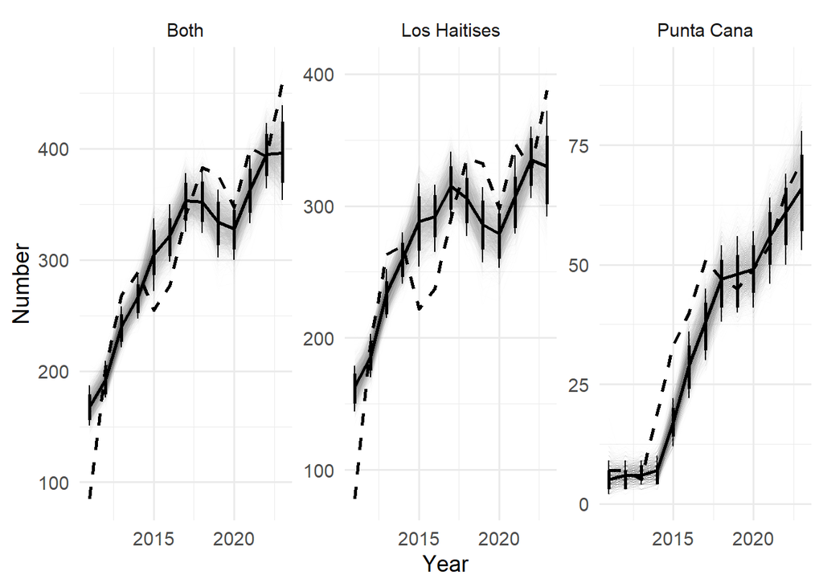

```r
#*******************
#* Plot IPM results
#*******************
#Plot population size
lNall <- melt(Nall)
colnames(lNall) <- c("Time", "Iter", "Abundance")
lNall$Site.ind <- 3; lNall$Site <- "Both"
lNall <- lNall[,c(1,4,2,3,5)]

Ntot <- outp$Ntot[1:13,,] # thin by 10 to speed up plotting
lN <- melt(Ntot)
colnames(lN) <- c("Time", "Site.ind", "Iter", "Abundance")
lN$Site <- ifelse(lN$Site.ind==1, "Los Haitises", "Punta Cana")
lN <- rbind(lN, lNall)

lN$Year <- lN$Time + 2010

med_hdis <- function(x, cm){
            df <- data.frame(y=median(x),
                             ymin=HDInterval::hdi(x, credMass=cm)[1],
                             ymax=HDInterval::hdi(x, credMass=cm)[2] )
}

counts.tot <- datl$countsAdults+datl$countsFY+constl$hacked.counts[,-3]
df.counts <- melt(counts.tot)
colnames(df.counts) <- c("Year", "Site_ab", "Count")
df.counts$Site <- ifelse(df.counts$Site_ab=="LHNP", "Los Haitises", "Punta Cana")

df.counts.all <- data.frame(Year=2011:2023, Site_ab="Both", Count=counts.tot[,1] + counts.tot[,2], Site="Both" )
df.counts <- rbind(df.counts, df.counts.all)

p1 <- ggplot() + theme_minimal(base_size=14) +
  geom_line(data=lN, aes(x=Year, y=Abundance, group=Iter),
            color="gray30", linewidth=0.1, alpha=0.01 ) +
  stat_summary(data=lN, aes(x=Year, y=Abundance),
               geom="errorbar", width=0,
               fun.data =med_hdis, fun.args=list(cm=0.95) ) +
  stat_summary(data=lN, aes(x=Year, y=Abundance),
               geom="errorbar", width=0, linewidth=1,
               fun.data =med_hdis, fun.args=list(cm=0.80) ) +
  stat_summary(data=lN, aes(x=Year, y=Abundance),
               geom="line", linewidth=1,
               fun.data =function(x){data.frame(y=median(x))} ) +
  geom_line(data=df.counts, aes(x=Year, y=Count),
            col="black", linewidth=1, linetype=2 ) +
  facet_wrap("Site", scales="free_y") +
  xlab("Year") + ylab("Number")
p1
```

```r
# ggsave(filename="C://Users//rolek.brian//OneDrive - The Peregrine Fund//Documents//Projects//Ridgways IPM//figs//Abundance and counts.tiff",
#        plot=p1,
#        device="tiff",
#        width=9, height=4, dpi=300)
```

### 1.2.1 Population Trends and Structure

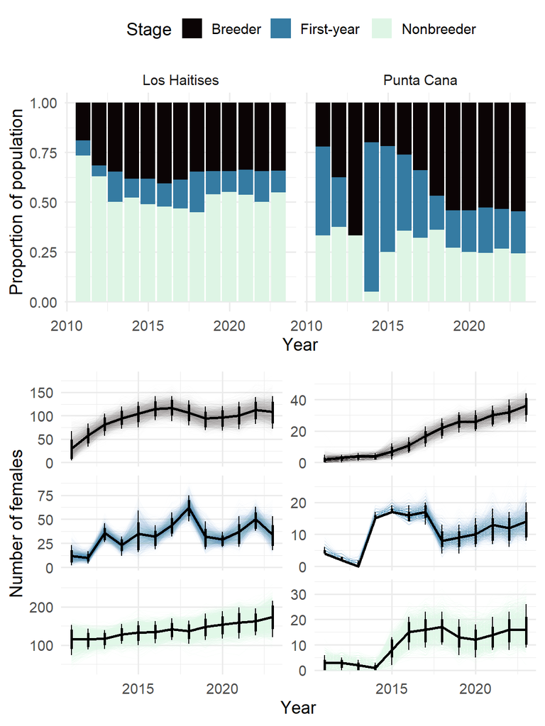

```r
# Plot life stage structure
mdFY <-  apply(outp$NFY[1:13,,], c(1,2), median)
mdB <-  apply(outp$NB[1:13,,], c(1,2), median)
mdF <-  apply(outp$NF[1:13,,], c(1,2), median)
lFY <- melt(mdFY)
lB <- melt(mdB)
lF <- melt(mdF)
lFY$Stage <- "First-year"
lB$Stage <- "Breeder"
lF$Stage <- "Nonbreeder"
ldat <- rbind(lFY, lB, lF)
colnames(ldat)[1:3] <- c("Year", "Sitenum", "Number")
ldat$Site <- ifelse(ldat$Sitenum==1, "Los Haitises", "Punta Cana")
ldat$year <- ldat$Year+2010

# Use median number of females in each stage
# to plot an approximate population structure
p3 <- ggplot(ldat, aes(fill=Stage, y=as.numeric(Number), x=year)) +
  geom_bar(position="fill", stat="identity") +
  ylab("Proportion of population") + xlab("Year") +
  facet_wrap("Site") +
  theme_minimal(base_size=14)+ theme(legend.position="top") +
  scale_fill_viridis_d(option = "mako")

p4 <- ggplot(ldat, aes(fill=Stage, y=as.numeric(Number), x=year)) +
  geom_bar(position="stack", stat="identity") +
  ylab("Median number of females") + xlab("Year") +
  facet_wrap("Site", scales = "free_y") +
  theme_minimal(base_size=14 ) + theme(legend.position="top") +
  scale_fill_viridis_d(option = "mako")

# plot with uncertainty
lFY <- melt(outp$NFY)
lB <- melt(outp$NB)
lF <- melt(outp$NF)
colnames(lFY) <- colnames(lB) <- colnames(lF) <- c("Time", "Site", "Iteration", "Abundance")
lFY$Year <- lFY$Time + 2010
lB$Year <- lB$Time + 2010
lF$Year <- lF$Time + 2010
lFY$Stage <- "First-year"
lB$Stage <- "Breeder"
lF$Stage <- "Nonbreeder"
lALL <- rbind(lFY, lB, lF)
lALL$Site <- ifelse(lALL$Site==1, "Los Haitises", "Punta Cana")

mdFY <-  apply(outp$NFY[1:13,,], c(1,2), median)
mdB <-  apply(outp$NB[1:13,,], c(1,2), median)
mdF <-  apply(outp$NF[1:13,,], c(1,2), median)
hdiFY <-  apply(outp$NFY[1:13,,], c(1,2), HDInterval::hdi)
hdiB <-  apply(outp$NB[1:13,,], c(1,2), HDInterval::hdi)
hdiF <-  apply(outp$NF[1:13,,], c(1,2), HDInterval::hdi)
medFY <- melt(mdFY)
medB <- melt(mdB)
medF <- melt(mdF)
hdisFY <- melt(hdiFY)
hdisB <- melt(hdiB)
hdisF <- melt(hdiF)
dfstages <- rbind(medFY, medB, medF)
dfhdis <- rbind(hdisFY, hdisB, hdisF)
dfstages$LHDI <- dfhdis[dfhdis$Var1=="lower",]
dfstages$UHDI <- dfhdis[dfhdis$Var1=="upper",]
cols <- mako(3)

med_hdis <- function(x, cm){
  df <- data.frame(y=median(x),
                   ymin=HDInterval::hdi(x, credMass=cm)[1],
                   ymax=HDInterval::hdi(x, credMass=cm)[2] )
}

p5 <- ggplot() +  theme_minimal(base_size=14) +
  theme(legend.position="none") +
  geom_line(data=lALL, aes(x=Year, y=Abundance,
                           group=Iteration, color=Stage,
                           alpha=Stage),
            linewidth=0.1) +
  stat_summary(data=lALL, aes(x=Year, y=Abundance),
               geom="errorbar", width=0,
               fun.data =med_hdis, fun.args=list(cm=0.95) ) +
  stat_summary(data=lALL, aes(x=Year, y=Abundance),
               geom="errorbar", width=0, linewidth=1,
               fun.data =med_hdis, fun.args=list(cm=0.80) ) +
  stat_summary(data=lALL, aes(x=Year, y=Abundance),
               geom="line", linewidth=1,
               fun.data =function(x){data.frame(y=median(x))} ) +
  scale_color_manual( values = c("First-year"=cols[2], "Breeder"=cols[1], "Nonbreeder"=cols[3])  ) +
  scale_alpha_manual( values = c("First-year"=0.015, "Breeder"=0.0075, "Nonbreeder"=0.15) ) +
  facet_wrap(Stage~Site, scales="free_y",
             shrink=TRUE, ncol=2) +
  xlab("Year") + ylab("Number of females") +
  theme(
    strip.background = element_blank(),
    strip.text.x = element_blank()
  )

p35 <- ggarrange(p3, p5, ncol=1, nrow=2)
p35
```

```r
# ggsave(filename="C://Users//rolek.brian//OneDrive - The Peregrine Fund//Documents//Projects//Ridgways IPM//figs//Stage structure_abundance.tiff",
#        plot=p35,
#        device="tiff",
#        width=6, height=8, dpi=300)
```

### 1.2.2 Apparent Survival, Recruitment, and Detection

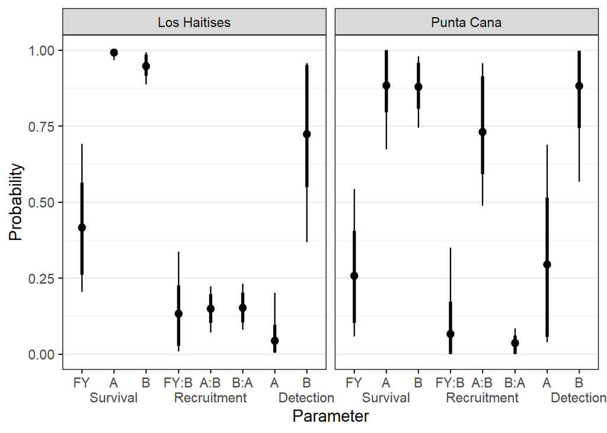

```r
# plot survival, recruitment, and detection
mus.mat <- outp$mus
dimnames(mus.mat)[[1]] <- c("FY",
                            "A\nSurvival", "B",
                            "FY:B",
                            "A:B\nRecruitment",
                            "B:A",
                            "A", "B\nDetection")
dimnames(mus.mat)[[2]] <- c("Los Haitises", "Punta Cana")
lmus <- melt(mus.mat)
colnames(lmus) <- c("Parameter", "Site", "Iter", "value")

p6 <- ggplot(data= lmus, aes(x=value, y=Parameter )) +
  stat_pointinterval(point_interval=median_hdci, .width = c(.95, .80)) +
  coord_flip() +
  facet_wrap("Site") +
  xlab("Probability") + ylab("Parameter") +
  theme_bw(base_size=14) +
  theme(panel.grid.major.x = element_blank(),
        panel.grid.minor.x = element_blank())

p6
```

```r
# ggsave(filename="C://Users//rolek.brian//OneDrive - The Peregrine Fund//Documents//Projects//Ridgways IPM//figs//Survival Recruitment Detection.tiff",
#        plot=p6,
#        device="tiff",
#        width=8, height=4, dpi=300)

# print estimates
mds <- tapply(lmus$value, list(lmus$Parameter, lmus$Site), median) |> round(2)
hdi_LH <- tapply(lmus$value, list(lmus$Parameter, lmus$Site), HDInterval::hdi)[,1]
hdi_LH2 <- do.call(rbind, hdi_LH) |> round(2)
hdi_PC <- tapply(lmus$value, list(lmus$Parameter, lmus$Site), HDInterval::hdi)[,2]
hdi_PC2 <- do.call(rbind, hdi_PC) |> round(2)
df <- data.frame(param= c("phiFY", "phiA", "phiB", "psiFY:B", "psiA:B", "psiB:A", "pA", "pB"),
  md_LH=mds[,1], lhdi_LH=hdi_LH2[,1], uhdi_LH=hdi_LH2[,2],
  md_PC=mds[,2], lhdi_PC=hdi_PC2[,1], uhdi_PC=hdi_PC2[,2])
df
```

|  | param | md_LH | lhdi_LH | uhdi_LH | md_PC | lhdi_PC | uhdi_PC |
| --- | --- | --- | --- | --- | --- | --- | --- |
| FY | phiFY | 0.42 | 0.20 | 0.69 | 0.26 | 0.06 | 0.54 |
| A\nSurvival | phiA | 0.99 | 0.97 | 1.00 | 0.88 | 0.67 | 1.00 |
| B | phiB | 0.95 | 0.89 | 0.99 | 0.88 | 0.74 | 0.98 |
| FY:B | psiFY:B | 0.13 | 0.01 | 0.34 | 0.07 | 0.00 | 0.35 |
| A:B\nRecruitment | psiA:B | 0.15 | 0.07 | 0.22 | 0.73 | 0.49 | 0.96 |
| B:A | psiB:A | 0.15 | 0.08 | 0.23 | 0.04 | 0.00 | 0.08 |
| A | pA | 0.04 | 0.00 | 0.20 | 0.29 | 0.04 | 0.69 |
| B\nDetection | pB | 0.72 | 0.37 | 0.96 | 0.88 | 0.57 | 1.00 |

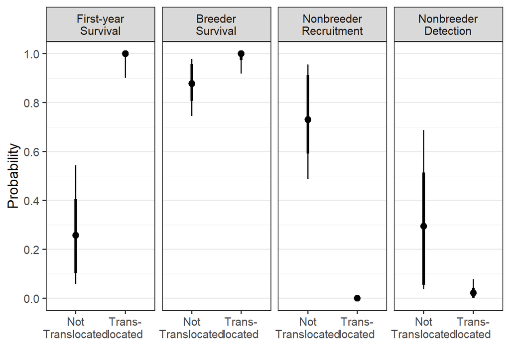

```r
# Plot predicted survival, recruitment, and detection
# with effects from translocation and hacking
# Birds were only hacked from LHNP to PC here
# so we only predict values for PC

betas.pd <- apply(outp$betas, 1, pd)
ind <- which (betas.pd>0.975) # which are significant
pred.mus <- array(NA, dim=c(dim(outp$mus)))
for (m in ind){
  for (tr in 1:2){
    pred.mus[m,tr,] <- plogis( outp$lmus[m,2,] + outp$betas[m,]*c(0,1)[tr] )
  }}
# treatment, mu, site, iter
mus.md <- apply(pred.mus, c(1,2), median)
mus.HDI80 <- apply(pred.mus, c(1,2), HDInterval::hdi, credMass=0.8)
mus.HDI95 <- apply(pred.mus, c(1,2), HDInterval::hdi)
dimnames(pred.mus) <- list(Params=c("First-year\nSurvival",
                                    "Nonbreeder\nSurvival",
                                    "Breeder\nSurvival",
                                    "First-year\nRecruitment",
                                    "Nonbreeder\nRecruitment",
                                    "Breeder to Nonbreeder\nTransition",
                                   "Nonbreeder\nDetection",
                                   "Breeder\nDetection"),
                           Translocated=c("Not Translocated",
                                          "Translocated"),
                           Iter=1:dim(pred.mus)[[3]])
lpms <- melt(pred.mus)
colnames(lpms)[[4]] <- "Probability"
lpms <- lpms[!is.na(lpms$Probability),]

p.betas <- ggplot(lpms, aes(x=Translocated, y=Probability) ) +
  stat_pointinterval(point_interval=median_hdci, .width = c(.95, .80)) +
  facet_wrap("Params", nrow=1) +
  theme_bw(base_size=14) +
  theme(panel.grid.major.x = element_blank(),
        panel.grid.minor.x = element_blank()) +
  xlab("") +
  scale_y_continuous(breaks = seq(0, 1, by = 0.2),
                     minor_breaks = seq(0, 1, by = 0.1)) +
  scale_x_discrete(labels=c("Not Translocated"="Not\nTranslocated",
                            "Translocated"="Trans-\nlocated"))

p.betas
```

```r
# ggsave(filename="C://Users//rolek.brian//OneDrive - The Peregrine Fund//Documents//Projects//Ridgways IPM//figs//Translocation effects_ggplot.tiff",
#        plot=p.betas,
#        device="tiff",
#        width=8, height=4, dpi=300)
```

### 1.2.3 Productivity

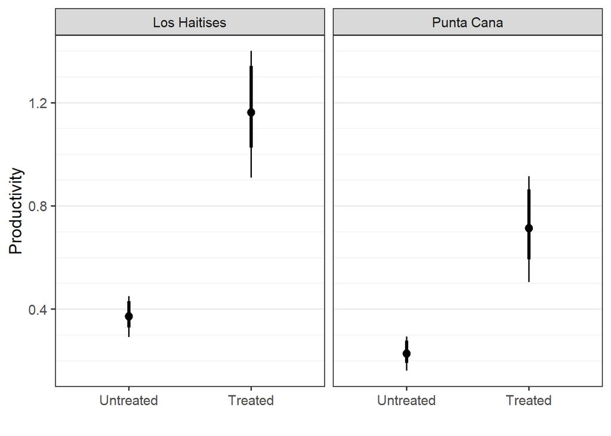

```r
# Plot fecundity in response to nest treatments
f <- exp(outp$lmu.prod)
f.md <- apply(f, 1, median)
f.HDI80 <- apply(f, 1, HDInterval::hdi, credMass=0.8)
f.HDI95 <- apply(f, 1, HDInterval::hdi)
rownames(f) <- c("Los Haitises", "Punta Cana")
lf <- melt(f)
colnames(lf) <- c("Site", "Iter", "Productivity")
lf$Treatment <- "Untreated"

# Calculate treatment effects on fecundity
f.pred <- array(NA, dim=dim(outp$lmu.prod))
for (s in 1:2){
  f.pred[s,] <- exp(outp$lmu.prod[s,] + outp$gamma[,1])
} # s
f2.md <- apply(f.pred, 1, median)
f2.HDI80 <- apply(f.pred, 1, HDInterval::hdi, credMass=0.8)
f2.HDI95 <- apply(f.pred, 1, HDInterval::hdi)
rownames(f.pred) <- c("Los Haitises", "Punta Cana")
lf.pred <- melt(f.pred)
colnames(lf.pred) <- c("Site", "Iter", "Productivity")
lf.pred$Treatment <- "Treated"
lprod <- rbind(lf,lf.pred)
lprod$Treatment <- factor(lprod$Treatment, levels=c('Untreated', 'Treated'))

p.prod <- ggplot(lprod, aes(x=Treatment, y=Productivity) ) +
            stat_pointinterval(point_interval=median_hdci, .width = c(.95, .80), expand=T) +
            facet_wrap("Site") +
            theme_bw(base_size=14) +
            theme(panel.grid.major.x = element_blank(),
                  panel.grid.minor.x = element_blank()) +
            xlab("")+
            scale_y_continuous(breaks = seq(0, 1.5, by = 0.4),
                               minor_breaks = seq(0, 1.5, by = 0.1))

p.prod
```

```r
# ggsave(filename="C://Users//rolek.brian//OneDrive - The Peregrine Fund//Documents//Projects//Ridgways IPM//figs//Fecundity_treatment_ggplot.tiff",
#        plot=p.prod,
#        device="tiff",
#        width=4, height=3, dpi=300)

# Calculate probability of direction
f.diff <- f[1,]-f[2,]
pd(f.diff) |> round(2)
```

```
## Probability of Direction: 1.00
```

```r
f.md |> round(2)
```

```
## lmu.prod[1] lmu.prod[2]
##        0.37        0.23
```

```r
f.HDI95 |> round(2)
```

```
##       lmu.prod[1] lmu.prod[2]
## lower        0.30        0.16
## upper        0.45        0.29
```

```r
f.diff2 <- f.pred[1,]-f.pred[2,]
pd(f.diff2) |> round(2)
```

```
## Probability of Direction: 1.00
```

```r
f2.md  |> round(2)
```

```
## [1] 1.16 0.71
```

```r
f2.HDI95 |> round(2)
```

```
##       [,1] [,2]
## lower 0.93 0.50
## upper 1.41 0.91
```

```r
median(f.pred[1,]/f[1,])
```

```
## [1] 3.116722
```

```r
median(f.pred[2,]/f[2,])
```

```
## [1] 3.116722
```

### 1.2.4 Correlations Among Demographic Rates and Detection

R is the correlation coefficent between rates. Indices for R are demographics and detection parameters in both dimensions. For example, R[1,2] is the correlation coefficient between first-year survival and nonbreeder survival.  
1. First-year Survival  
2. Nonbreeder Survival  
3. Breeder Survival  
4. First-year recruitment to breeder  
5. Nonbreeder recruitment to breeder  
6. Breeder transition to nonbreeder  
7. Nonbreeder detection  
8. Breeder detection  
9. Productivity

```r
#*******************
# Correlations among demographic rates and detection
#*******************
pdR <- apply(outp$R, c(1,2), pd) |> round(2)
max(pdR[pdR<1])
```

```
## [1] 0.82
```

```r
apply(outp$R, c(1,2), median) |> round(2)
```

```
##        [,1]  [,2]  [,3]  [,4]  [,5]  [,6]  [,7]  [,8]  [,9]
##  [1,]  1.00  0.01  0.23  0.10  0.05  0.01  0.08  0.15 -0.08
##  [2,]  0.01  1.00  0.04 -0.06 -0.01  0.00  0.00  0.07 -0.10
##  [3,]  0.23  0.04  1.00 -0.04 -0.01  0.00  0.25  0.03 -0.13
##  [4,]  0.10 -0.06 -0.04  1.00 -0.02 -0.01  0.20 -0.18 -0.15
##  [5,]  0.05 -0.01 -0.01 -0.02  1.00 -0.03 -0.01  0.09 -0.12
##  [6,]  0.01  0.00  0.00 -0.01 -0.03  1.00 -0.02  0.05  0.04
##  [7,]  0.08  0.00  0.25  0.20 -0.01 -0.02  1.00 -0.22 -0.20
##  [8,]  0.15  0.07  0.03 -0.18  0.09  0.05 -0.22  1.00  0.09
##  [9,] -0.08 -0.10 -0.13 -0.15 -0.12  0.04 -0.20  0.09  1.00
```

```r
apply(outp$R, c(1,2), HDInterval::hdi)[1,,] |> round(2)
```

```
##        [,1]  [,2]  [,3]  [,4]  [,5]  [,6]  [,7]  [,8]  [,9]
##  [1,]  1.00 -0.61 -0.31 -0.52 -0.56 -0.61 -0.52 -0.35 -0.55
##  [2,] -0.61  1.00 -0.53 -0.60 -0.59 -0.59 -0.58 -0.47 -0.69
##  [3,] -0.31 -0.53  1.00 -0.53 -0.59 -0.60 -0.30 -0.40 -0.59
##  [4,] -0.52 -0.60 -0.53  1.00 -0.56 -0.55 -0.30 -0.68 -0.63
##  [5,] -0.56 -0.59 -0.59 -0.56  1.00 -0.67 -0.52 -0.46 -0.69
##  [6,] -0.61 -0.59 -0.60 -0.55 -0.67  1.00 -0.54 -0.61 -0.53
##  [7,] -0.52 -0.58 -0.30 -0.30 -0.52 -0.54  1.00 -0.60 -0.65
##  [8,] -0.35 -0.47 -0.40 -0.68 -0.46 -0.61 -0.60  1.00 -0.42
##  [9,] -0.55 -0.69 -0.59 -0.63 -0.69 -0.53 -0.65 -0.42  1.00
```

```r
apply(outp$R, c(1,2), HDInterval::hdi)[2,,] |> round(2)
```

```
##       [,1] [,2] [,3] [,4] [,5] [,6] [,7] [,8] [,9]
##  [1,] 1.00 0.58 0.70 0.63 0.58 0.57 0.62 0.63 0.40
##  [2,] 0.58 1.00 0.60 0.59 0.59 0.60 0.61 0.69 0.51
##  [3,] 0.70 0.60 1.00 0.53 0.55 0.58 0.72 0.48 0.33
##  [4,] 0.63 0.59 0.53 1.00 0.53 0.60 0.71 0.34 0.44
##  [5,] 0.58 0.59 0.55 0.53 1.00 0.55 0.60 0.58 0.40
##  [6,] 0.57 0.60 0.58 0.60 0.55 1.00 0.62 0.62 0.64
##  [7,] 0.62 0.61 0.72 0.71 0.60 0.62 1.00 0.23 0.32
##  [8,] 0.63 0.69 0.48 0.34 0.58 0.62 0.23 1.00 0.54
##  [9,] 0.40 0.51 0.33 0.44 0.40 0.64 0.32 0.54 1.00
```

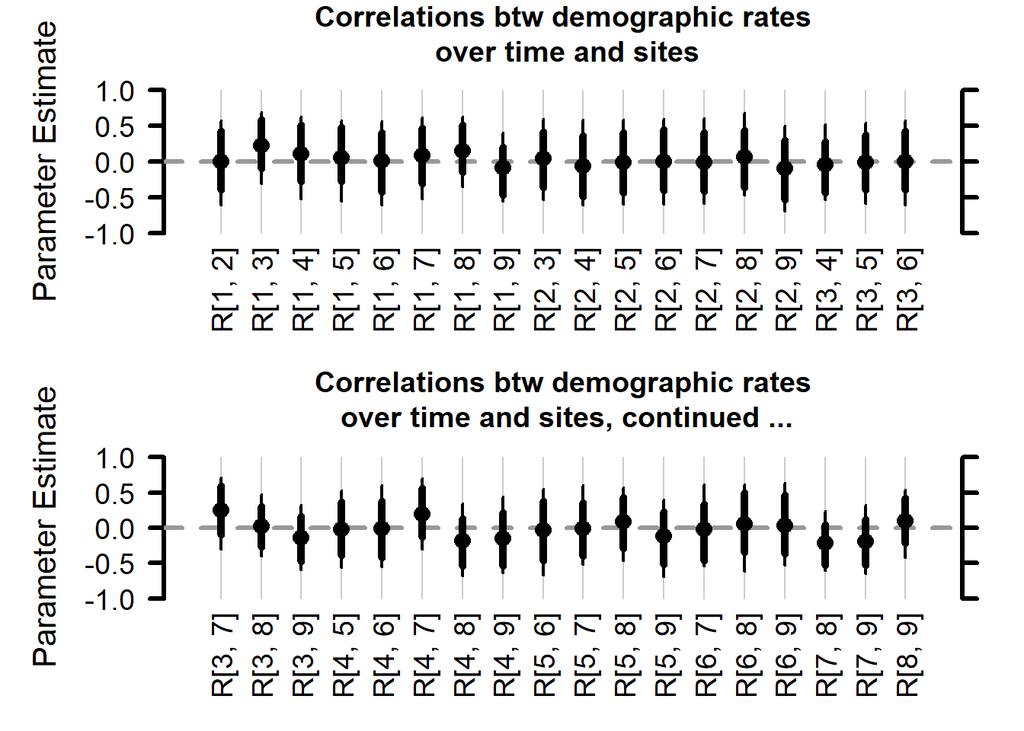

```r
plt  <- function(object, params,...) {
  MCMCplot(object=out,
           params=params,
           guide_axis=TRUE,
           HPD=TRUE, ci=c(80, 95), horiz=FALSE,
           #ylim=c(-10,10),
           ...)
}

ind <- 1
Rs <- c()
for (i in 1:(nrow(outp$R)-1)){
  for (j in (i+1):nrow(outp$R)){
    Rs[ind] <- paste0("R[",i,", ", j, "]")
    ind <- ind+1
  }}
par(mfrow=c(2,1))
plt(object=out, params=Rs[1:18], exact=TRUE, ISB=FALSE,
    main="Correlations btw demographic rates\n over time and sites",
    xlab = "Rhos", guide_lines=TRUE)
plt(object=out, params=Rs[19:36], exact=TRUE, ISB=FALSE,
    main="Correlations btw demographic rates\n over time and sites, continued ...",
    xlab = "Rhos", guide_lines=TRUE)
```

### 1.2.5 Population Growth Rates Over Time

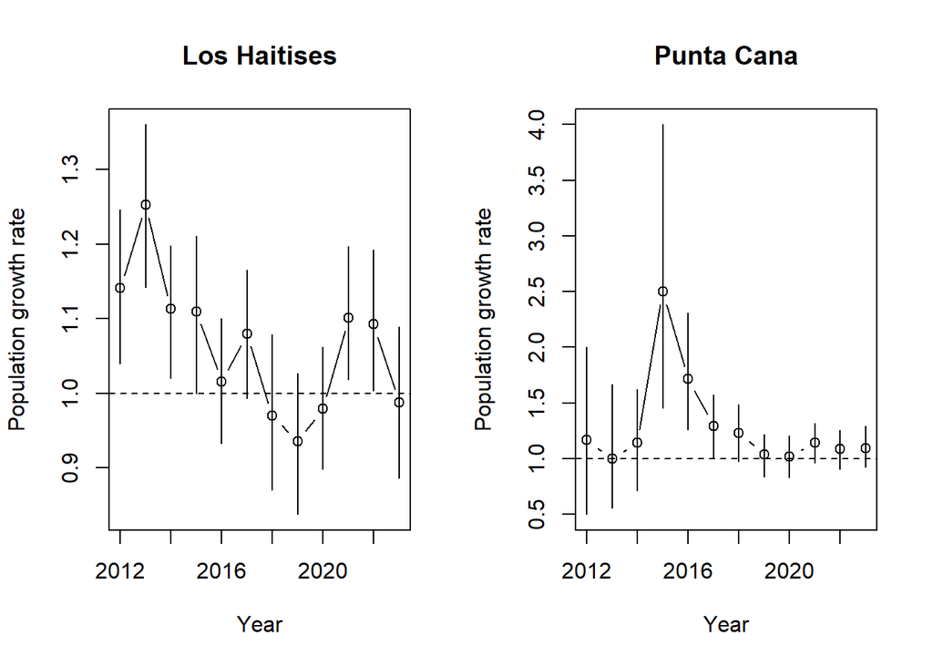

```r
#*******************
# Population growth rates over time
#*******************
lam.m <- apply(outp$lambda[1:12,,], c(1,2), median)
lam.hdi <- apply(outp$lambda[1:12,,], c(1,2), HDInterval::hdi)
par(mfrow=c(1,2))
plot(2012:2023, lam.m[,1], type="b", pch=1,
     ylab="Population growth rate", xlab="Year",
     ylim=c(min(lam.hdi[,,1]), max(lam.hdi[,,1])),
     main="Los Haitises")
abline(h=1, lty=2)
segments(x0=2012:2023, x1=2012:2023,
         y0 = lam.hdi[1,,1], y1= lam.hdi[2,,1])

plot(2012:2023, lam.m[,2], type="b", pch=1, lty=1,
     ylab="Population growth rate", xlab="Year",
     ylim=c(min(lam.hdi[,,2]), max(lam.hdi[,,2])),
     main="Punta Cana")
abline(h=1, lty=2)
segments(x0=2012:2023, x1=2012:2023,
         y0 = lam.hdi[1,,2], y1= lam.hdi[2,,2])
```

### 1.2.6 Correlations Between Population Growth Rates and Demographics

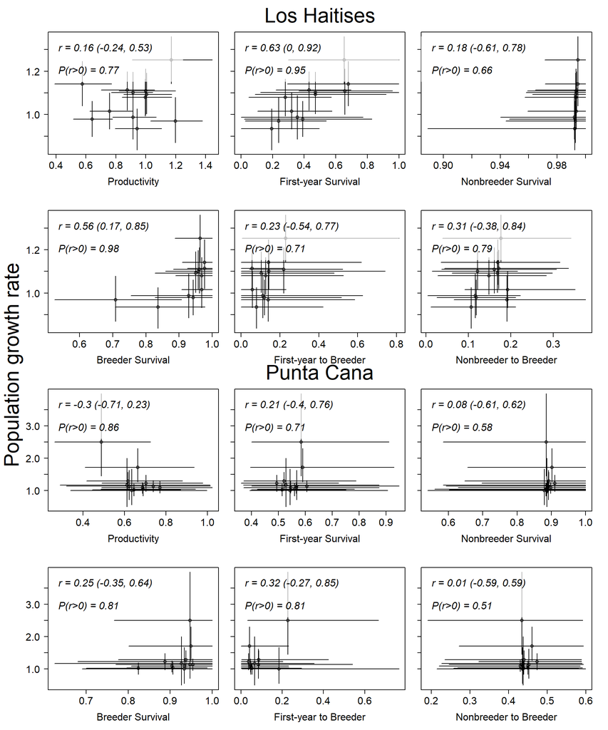

```r
#*******************
# Correlations between demographics and population growth rates
#*******************
# create a function to plot correlations
# between demographics and population growth rates
plot.cor <- function (lam.post, x.post, x.lab, ind.x=1:12, ind.y=1:12, site=1, yaxt="b"){
  # calculate the correlation coefficient
  # over each iteration to propagate error
  lambda <- lam.post[ind.y, site,]
  x <- x.post[ind.x, site, ]
  df <- data.frame(ats1=c(0.8, 0.9, 1.0, 1.1, 1.2, 1.3),
                   ats2=c(1.0, 1.5, 2.0, 2.5, 3.0, 3.5),
                   labs1=c("0.8", NA, "1.0", NA, "1.2", NA),
                   labs2=c("1.0", NA, "2.0", NA, "3.0", NA)
  )
  if(site==1){ df <- df[, c(1,3)]} else{
    df <- df[, c(2,4)]
  }
  lwd <- 1

  cor.post <- array(NA, dim=dim(lambda)[-1])
    for (i in 1:dim(lambda)[[2]]){
      cor.post[i] <- cor(lambda[,i], x[,i])
    }
  cor.df <- data.frame(median= median(cor.post) |> round(digits=2),
                       ldi=HDInterval::hdi(cor.post)[1] |> round(digits=2),
                       hdi=HDInterval::hdi(cor.post)[2] |> round(digits=2),
                       pd = pd(cor.post) |> round(digits=2))

  lam.m <- apply(lambda, 1, median)
  lam.hdi <- apply(lambda, 1, HDInterval::hdi)
  x.m <- apply(x, 1, median)
  x.hdi <- apply(x, 1, HDInterval::hdi)
    x.lims <- c(min(x.hdi[,]), max(x.hdi[,]))
    y.lims <- c(min(lam.hdi[,]), max(lam.hdi[,]))
    if(yaxt=="n"){
    plot(x.m, lam.m[ind.y],
         xlim= x.lims,
         ylim= y.lims,
         type="n",
         ylab="", xlab=x.lab, cex.lab=1.5,
         main=c("", "")[site],
         yaxt=yaxt, xaxt="n")
      axis(2, at=df[,1], labels=c(rep(NA, 5)))
    } else {
      plot(x.m, lam.m[ind.y],
           xlim= x.lims,
           ylim= y.lims,
           type="n",
           ylab="", xlab=x.lab, cex.lab=1.5,
           main=c("", "")[site],
           yaxt="n", xaxt="n")
      axis(2, at=df[,1], labels=df[,2], las=1, cex.axis=1.5)
    }
    axis(1, cex.axis=1.5)
    points(x.m, lam.m, pch=1)
    segments(x0=x.hdi[1,], x1=x.hdi[2,],
             y0 = lam.m, y1= lam.m, lwd=lwd)
    segments(x0=x.m, x1=x.m,
             y0 = lam.hdi[1,], y1= lam.hdi[2,], lwd=lwd)
    xs <- c(x.lims[1], x.lims[1]+(x.lims[2]-x.lims[1]*1.5))
    ys <- c( (y.lims[2]-y.lims[1])+y.lims[1], (y.lims[2]-y.lims[1])+y.lims[1],
             (y.lims[2]-y.lims[1])*0.6+y.lims[1], (y.lims[2]-y.lims[1])*0.6+y.lims[1])
    polygon(x=c(xs, rev(xs)), y=ys, col=alpha("white", 0.7), border=NA )
    text(x = x.lims[1], y = (y.lims[2]-y.lims[1])*0.9+y.lims[1],
         paste("r = ", cor.df$median, " (",cor.df$ldi,", ", cor.df$hdi, ")", sep=""),
         pos = 4, font = 3, cex = 1.5)
    text(x = x.lims[1], y = (y.lims[2]-y.lims[1])*0.7+y.lims[1], paste("P(r>0) = ", cor.df$pd, sep=""),
         pos = 4, font = 3, cex = 1.5)

  }

# Plot correlations between population growth rates
# and demographics.
# "r" is a correlation coefficient and represents
# the magnitude of the correlation
# P(r>0) is the probability of direction (similar to p-values)
# that is, the probability that an effect exists
# tiff(height=8, width=8, units="in", res=300,
#      filename= "C://Users//rolek.brian//OneDrive - The Peregrine Fund//Documents//Projects//Ridgways IPM//figs//PopGrowthand Demographics1.tiff")
par(mfrow=c(4,3), mar=c(4,1,3,1), oma=c(1,5,1,1))
plot.cor(outp$lambda, outp$mn.prod, x.lab="Productivity", ind.x=2:13)
plot.cor(outp$lambda, outp$mn.phiFY, x.lab="First-year Survival", yaxt="n")
mtext("Los Haitises", side=3, line=1, cex=2)
plot.cor(outp$lambda, outp$mn.phiA, x.lab="Nonbreeder Survival", yaxt="n")
plot.cor(outp$lambda, outp$mn.phiB, x.lab="Breeder Survival")
plot.cor(outp$lambda, outp$mn.psiFYB, x.lab="First-year to Breeder", yaxt="n")
plot.cor(outp$lambda, outp$mn.psiAB, x.lab="Nonbreeder to Breeder", yaxt="n")

# tiff(height=4, width=8, units="in", res=300,
#      filename= "C://Users//rolek.brian//OneDrive - The Peregrine Fund//Documents//Projects//Ridgways IPM//figs//PopGrowthand Demographics2.tiff")
# par(mfrow=c(2,3), mar=c(4,1,1,1), oma=c(0,5,3,0))
plot.cor(outp$lambda, outp$mn.prod, x.lab="Productivity", ind.x=2:13, site=2)
plot.cor(outp$lambda, outp$mn.phiFY, x.lab="First-year Survival", yaxt="n", site=2)
mtext("Punta Cana", side=3, line=1, cex=2)
plot.cor(outp$lambda, outp$mn.phiA, x.lab="Nonbreeder Survival", yaxt="n", site=2)
plot.cor(outp$lambda, outp$mn.phiB, x.lab="Breeder Survival", site=2)
plot.cor(outp$lambda, outp$mn.psiFYB, x.lab="First-year to Breeder", yaxt="n", site=2)
plot.cor(outp$lambda, outp$mn.psiAB, x.lab="Nonbreeder to Breeder", yaxt="n", site=2)

mtext("Population growth rate", side=2, outer=TRUE, line=2.5, cex=2)
```

```r
# dev.off()
```

### 1.2.7 Population Growth Rates and Contributions from Demographics

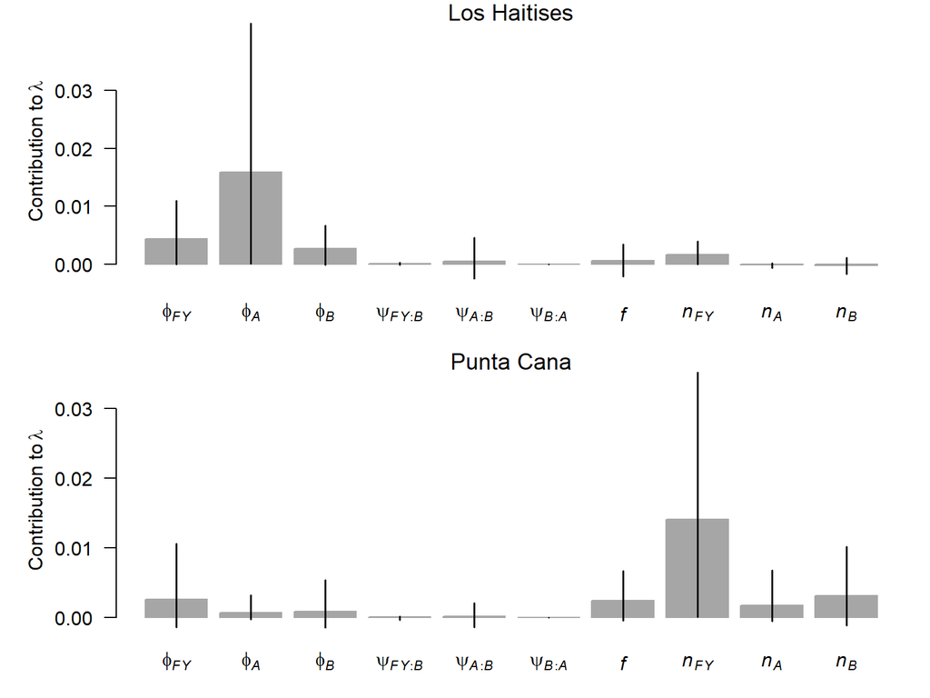

```r
#********************
# Transient Life Table Response Experiment (tLTRE)
# Overall contributions
#********************
lambda <- expression( ( # numerator start
                      (nfy*phiFY*psiFYB*f*0.5 + # repro of first year breeders
                       nf*phiA*psiAB*f*0.5 + # repro of nonbreeders to breeders
                       nb*phiB*(1-psiBA)*f*0.5) + # repro of breeders remaining breeders
                       nfy*phiFY*(1-psiFYB)  +
                       nf*phiA*(1-psiAB) +
                       nb*phiB*psiBA +
                       nfy*phiFY*psiFYB +
                       nb*phiB*(1-psiBA) ) / # numerator end
                       (nfy+nf+nb) # denominator
                      ) # expression end

# Calculate proportional population sizes
nyr <- nrow(outp$NFY)-1
niter <- dim(outp$NFY)[[3]]
n1 <- outp$NFY[1:nyr, ,] / outp$Ntot[1:nyr, ,]
n2 <- outp$NF[1:nyr, ,] / outp$Ntot[1:nyr, ,]
n3 <- outp$NB[1:nyr, ,] / outp$Ntot[1:nyr, ,]

# Extract the mean demographic rates and population sizes and store them in a list
mu <- list(phiFY=outp$mus[1,,], phiA=outp$mus[2,,], phiB=outp$mus[3,,],
           psiFYB=outp$mus[4,,], psiAB=outp$mus[5,,], psiBA=outp$mus[6,,],
           f=exp(outp$lmu.prod),
           nfy=apply(n1, c(2,3), mean), nf=apply(n2, c(2,3), mean), nb=apply(n3, c(2,3), mean))

# Calculate sensitivities
nms <- c('phiFY', 'phiA', 'phiB',
          'psiFYB', 'psiAB', 'psiBA',
          'f',
          'nfy', 'nf', 'nb' )
sens.func <- function( name, expr=lambda, envir=mu) { eval(D(expr=expr, name=name), envir=envir) }
sensl <- lapply(nms, sens.func)
names(sensl) <- nms
sens <- abind(sensl, along=3)

# Define matrix to store results
cont <- array(NA, dim=c(2, niter, 10) )
dimnames(cont)[[3]] <- nms

# Calculate contributions for each demographic rate and stage-structured population size at each MCMC draw
for (i in 1:niter){
  for (s in 1:2){
  dp_stoch <- cbind(outp$mn.phiFY[1:12,s,i], outp$mn.phiF[1:12,s,i], outp$mn.phiB[1:12,s,i],
                    outp$mn.psiFYB[1:12,s,i], outp$mn.psiAB[1:12,s,i], outp$mn.psiBA[1:12,s,i],
                    outp$mn.prod[2:13,s,i],
                    n1[1:12,s,i], n2[1:12,s,i], n3[1:12,s,i])
  # Derive process variance and covariance among demographic parameters using shrunk estimates of
  #     demographic rates and proportional pop. sizes
  dp_varcov <- var(dp_stoch)
  sensvec <- sens[s, i, ]
  # Calculate demographic contributions
  contmatrix <- dp_varcov * outer(sensvec, sensvec)
  cont[s, i,  ] <- rowSums(contmatrix)
}}

CRI <- apply(cont[,,], c(1,3), quantile, probs=c(0.025, 0.975))
names.arg <- c(expression(italic(phi)[italic(FY)]),
               expression(italic(phi)[italic(A)]),
               expression(italic(phi)[italic(B)]),
               expression(italic(psi)[italic(FY:B)]),
               expression(italic(psi)[italic(A:B)]),
               expression(italic(psi)[italic(B:A)]),
               expression(italic(f)),
               expression(italic(n)[italic(FY)]),
               expression(italic(n)[italic(A)]),
               expression(italic(n)[italic(B)]))
# tiff(height=4, width=6, units="in", res=300,
#      filename= "C://Users//rolek.brian//OneDrive - The Peregrine Fund//Documents//Projects//Ridgways IPM//figs//LTRE_overall.tiff")
par(mfrow=c(2,1), mar=c(3,5,1,1))
a <- barplot(colMeans(cont[1,,]), names.arg=names.arg,
             ylab=expression( paste("Contribution to ", lambda) ), las=1,
             ylim=range(CRI[,1,]), col=rep("grey65", 10),
             border=rep("grey65", 10),
             main="Los Haitises", font.main=1,
             yaxt="n")
axis(2, at=c(0, 0.01, 0.02, 0.03), las=1)
segments(a, CRI[1,1,], a, CRI[2,1,], lwd=1.5)

b <- barplot(colMeans(cont[2,,]), names.arg=names.arg,
             ylab=expression( paste("Contribution to ", lambda) ), las=1,
             ylim=range(CRI[,2,]), col=rep("grey65", 10),
             border=rep("grey65", 10),
             main="Punta Cana", font.main=1,
             yaxt="n")
axis(2, at=c(0, 0.01, 0.02, 0.03), las=1)
segments(a, CRI[1,2,], a, CRI[2,2,], lwd=1.5)
```

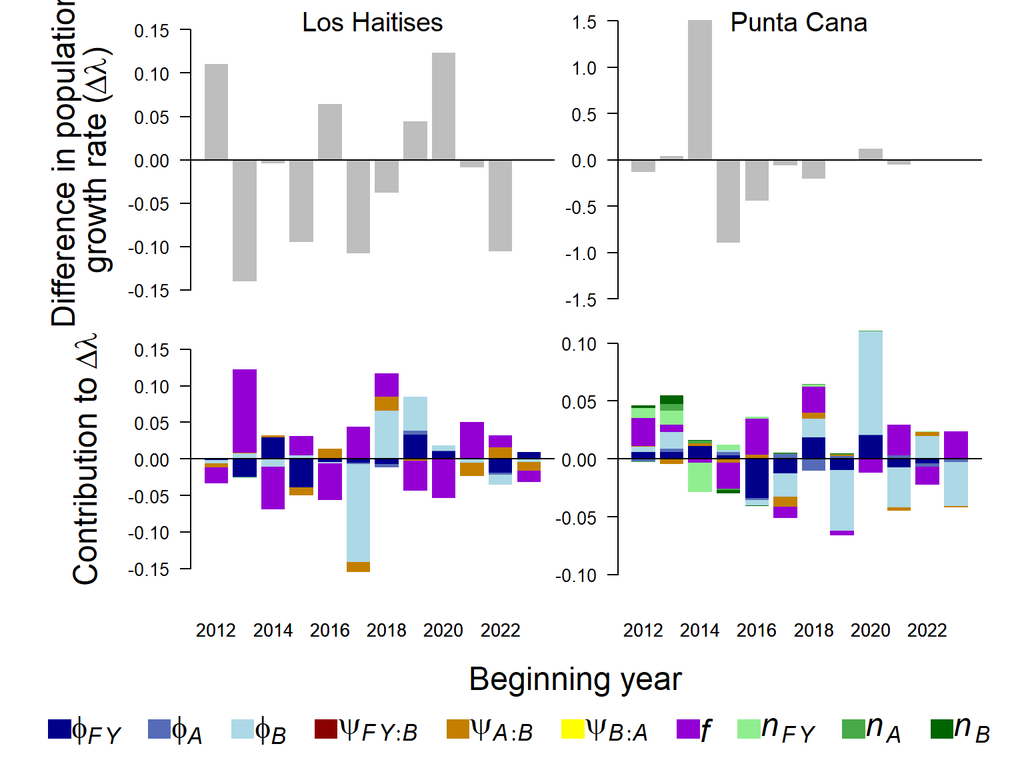

```r
# dev.off()

#*******************
# Transient Life Table Response Experiment (tLTRE)
# Inter-annual Contributions
#*******************
sens <- diff <- array(NA, dim=c(constl$nyr-1, 2, 10, dim(outp$mn.phiA)[[3]]),
              dimnames=list(Year=2012:2023,
                            site=c('Los Haitises', 'Punta Cana'),
                            Param=c('phiFY', 'phiA', 'phiB',
                                      'psiFYB', 'psiAB', 'psiBA',
                                      'f',
                                      'nfy', 'nf', 'nb' ),
                            Iter=1:dim(outp$mn.phiA)[[3]]) )

getDiff <- function(x){
            x[2:constl$nyr, , ] - x[1:(constl$nyr-1), , ]
}
diff[,,'phiFY',] <- getDiff(outp$mn.phiFY)
diff[,,'phiA',] <- getDiff(outp$mn.phiA)
diff[,,'phiB',] <- getDiff(outp$mn.phiB)
diff[,,'psiFYB',] <- getDiff(outp$mn.psiFYB)
diff[,,'psiAB',] <- getDiff(outp$mn.psiAB)
diff[,,'psiBA',] <- getDiff(outp$mn.psiBA)
diff[,,'f',] <- getDiff(outp$mn.prod)
diff[,,'nfy',] <- getDiff( outp$NFY/outp$Ntot )
diff[,,'nf',] <- getDiff( outp$NF/outp$Ntot )
diff[,,'nb',] <- getDiff( outp$NB/outp$Ntot )

getMn <- function(x) {
  ( x[2:constl$nyr, , ] + x[1:(constl$nyr-1), , ] ) / 2
}
means <- list('phiFY' = getMn(outp$mn.phiFY),
              'phiA' = getMn(outp$mn.phiA),
              'phiB' = getMn(outp$mn.phiB),
              'psiFYB' = getMn(outp$mn.psiFYB),
              'psiAB' = getMn(outp$mn.psiAB),
              'psiBA' = getMn(outp$mn.psiBA),
              'f' = getMn(outp$mn.prod),
              'nfy' = getMn(outp$NFY),
              'nf' = getMn(outp$NF),
              'nb' =  getMn(outp$NB) )

sens[,,'phiFY',] <- eval( D(lambda, "phiFY" ), envir = means )
sens[,,'phiA',] <- eval( D(lambda, "phiA" ), envir = means )
sens[,,'phiB',] <- eval( D(lambda, "phiB" ), envir = means )
sens[,,'psiFYB',] <- eval( D(lambda, "phiFYB" ), envir = means )
sens[,,'psiAB',] <- eval( D(lambda, "psiAB" ), envir = means )
sens[,,'psiBA',] <- eval( D(lambda, "psiBA" ), envir = means )
sens[,,'f',] <- eval( D(lambda, "f" ), envir = means )
sens[,,'nfy',] <- eval( D(lambda, "nfy" ), envir = means )
sens[,,'nf',] <- eval( D(lambda, "nf" ), envir = means )
sens[,,'nb',] <- eval( D(lambda, "nb" ), envir = means )

conts <- diff*sens

# ~~~~ figure 9.7 ~~~~
# Create a plot for the sequential differences in finite growth rates
niter <- dim(outp$mn.phiA)[[3]]
nyrs <- constl$nyr-1
diff.lam <- outp$lambda[2:nyrs, , ] - outp$lambda[1:(nyrs-1), ,]
differences <- cbind(2012:2022, apply(diff.lam, c(1,2), mean))
differences <- rbind(differences, c(2023, NA, NA))

# Mean contributions
V <- apply(conts, 3:1, mean)
V1 <- V2 <- V
V1[V1<0] <- 0
V2[V2>0] <- 0

# Make figure
colors <- c(colorRampPalette(c("blue4", "lightblue"))(3),
             colorRampPalette(c("darkred", "yellow"))(3),
             colorRampPalette(c("darkviolet"))(1),
             colorRampPalette(c("lightgreen", "darkgreen"))(3))

legend.text <- c(expression(italic(phi)[italic(FY)]),
                 expression(italic(phi)[italic(A)]),
                 expression(italic(phi)[italic(B)]),
                 expression(italic(psi)[italic(FY:B)]),
                 expression(italic(psi)[italic(A:B)]),
                 expression(italic(psi)[italic(B:A)]),
                 expression(italic(f)),
                 expression(italic(n)[italic(FY)]),
                 expression(italic(n)[italic(A)]),
                 expression(italic(n)[italic(B)]))

# tiff(height=6.5, width=8, units="in", res=300,
#      filename= "C://Users//rolek.brian//OneDrive - The Peregrine Fund//Documents//Projects//Ridgways IPM//figs//LTRE.tiff")
par(mfrow=c(2,2), mar=c(1, 2, 0, 1), oma=c(7,7,1,1))
txt.size <- 1.5
yl <- list(bquote( paste("Difference in population")),
         bquote( paste("growth rate (", Delta, lambda, ")" )) )
barplot(differences[,2], ylim=c(-0.16, 0.16),
        #ylab=expression( paste("Difference in population", "\ngrowth rate (", Delta, lambda, ")" )),
        ylab= "",
        xpd=NA,
        axes=FALSE, border=NA,
        cex.lab=txt.size, main="Los Haitises", cex.main=txt.size,
        font.main=1 )
mtext(do.call(expression,yl), side=2, cex=txt.size,
      line=c(5,3.5) )
axis(2, las=1)
abline(h=0)

barplot(differences[,3], ylim=c(-1.5, 1.5),
        ylab="",
        xpd=NA,
        axes=FALSE, border=NA, main="Punta Cana",
        cex.main=txt.size,
        font.main=1)
axis(2, las=1)
abline(h=0)

barplot(V1[,1,], ylim=c(-0.19, 0.19),
        col=colors, ylab="",
        xlab="",
        xpd=NA,
        axes=FALSE,
        border=NA,
        cex.lab=txt.size)
mtext(expression( paste("Contribution to ", Delta, lambda) ), side=2, cex=txt.size,
      line=4.25)
barplot(V2[,1,], add=TRUE, col=colors, axes=FALSE, border=NA)
axis(2, las=1)
abline(h=0)

barplot(V1[,2,], ylim=c(-0.12, 0.12),
        col=colors, ylab="",
        xlab="", axes=FALSE,
        names.arg=2012:2023,
        border=NA)
barplot(V2[,2,], add=TRUE, col=colors, axes=FALSE, border=NA)
axis(2, las=1)
abline(h=0)
mtext(side=1 , outer=TRUE, "Beginning year", line=2.5, cex=txt.size)
reset <- function() {
  par(mfrow=c(1, 1), oma=rep(0, 4), mar=rep(0, 4), new=TRUE)
  plot(0:1, 0:1, type="n", xlab="", ylab="", axes=FALSE)
}
reset()
legend(legend = legend.text, fill=colors,
       bty="n", x="bottom", border=NA,
       xpd=NA, x.intersp=0.005, text.width=NA,
       cex=1.5, horiz=TRUE)
```

```r
# dev.off()

#*******************
```

# 2. Population Viability Analysis (PVA)

## 2.1 Model Code

Code for Population Viability Analysis.

```r
library('nimble')
library('parallel')
library ('coda')

load("/bsuscratch/brianrolek/riha_ipm/data.rdata")
source("/bsuscratch/brianrolek/riha_ipm/MCMCvis.R")
load("/bsuscratch/brianrolek/riha_ipm/outputs/ipm_shortrun.rdata")

load("C://Users//rolek.brian//OneDrive - The Peregrine Fund//Documents//Projects//Ridgways IPM//outputs//ipm_longrun.rdata")
load("data//data.rdata")
library ("MCMCvis")

#**********************
#* Set data to reflect PVA scenarios
#**********************
cpus <- 5 # number of processors
constl$K <- 50 # number of future years
constl$SC <- 45 # number of PVA scenarios
datl$constraint_data <- rbind(datl$constraint_data, array(1, dim=c(constl$K,2)) ) # to help constrain FYs born + hacked to be positive
constl$effort2 <- rbind(constl$effort2, array(0, dim=c(constl$K,2), dimnames=list(2024:(2024+constl$K-1), c("LH", "PC"))))

constl$num.treated <- rep( c(0, 15, 30, 45, 100, 0, 15, 30, 45, 100, 0, 15, 30, 45, 100), each=3 ) # 100s sub in for All but are over-ridden in model code
num.hacked <- rep( c(0, 0, 0, 0, 0, 5, 5, 5, 5, 5, 10, 10, 10, 10, 10), each=3 )
surv.diff <- array(NA, dim=c(constl$SC, 3, 2), dimnames=list(scenario=1:constl$SC, stage=c('FY', 'NB', 'B'), site=c('LH', 'PC')))
surv.diff[,1,] <- matrix(c(rep( c(0, 0.130, 0.260), 15),
                           rep( c(0, 0.146, 0.292), 15)), ncol=2)
surv.diff[,2,] <- matrix(c(rep( c(0, 0.006, 0.012), 15),
                           rep( c(0, 0.022, 0.044), 15)), ncol=2)
surv.diff[,3,] <- matrix(c(rep( c(0, 0.016, 0.032), 15),
                           rep( c(0, 0.026, 0.052), 15)), ncol=2)
constl$surv.diff <- surv.diff

hacked.counts <- array(0, dim=c(constl$SC, constl$nyr+constl$K, 2))
for (sc in 1:constl$SC){
  hacked.counts[sc,1:constl$nyr, 1:2] <- constl$hacked.counts[, 1:2]
  hacked.counts[sc,14:(constl$nyr+constl$K), 1] <- -num.hacked[sc]
  hacked.counts[sc,14:(constl$nyr+constl$K), 2] <-  num.hacked[sc]
}
constl$hacked.counts <- hacked.counts

#**********************
#* Specify initial values
#* from posterior of IPM
#**********************
#* This helps ensure that all chains run
# Identify chains with NAs that failed to initialize
out <- lapply(post, as.mcmc)
NAlist <- c()
for (i in 1:length(out)){
  NAlist[i] <- any (is.na(out[[i]][,1:286]) | out[[i]][,1:286]<0)
}
out <- out[!NAlist]
outp <- MCMCpstr(out, type="chains")
!NAlist

Ni.func <- function (){
  # take the means of the posterior for inits
  Ni <- apply(outp$N, c(1,2,3), mean) |> round()
  Ni.pva <- array(NA, dim=c(constl$SC, dim(Ni)+c(0,constl$K,0)))
  for (sc in 1:constl$SC){
    Ni.pva[sc, 1:7, 1:constl$nyr, 1:2] <- Ni
    for (t in constl$nyr:(constl$nyr+constl$K)){
      for (s in 1:2){
        Ni.pva[sc, 1:7, t, s] <- Ni[1:7, 13, s]
      }}} # t sc
  return(Ni.pva)
} # function

u2 <- apply(outp$Ustar, c(1,2), mean)

inits.func.pva <- function (){
  list(
    # fecundity
    lmu.prod = apply(outp$lmu.prod, 1, mean),
    gamma = mean(outp$gamma),
    rr = mean(outp$rr),
    # survival
    z = par_info[[1]]$inits$z,
    mus = apply(outp$mus, c(1,2), mean),
    betas = apply(outp$betas, 1, mean),
    deltas = apply(outp$deltas, 1, mean),
    sds =  apply(outp$sds, 1, mean),
    Ustar = u2,
    # counts
    countsAdults= matrix(c(374, 335, 305, 295, rep(NA, length(2015:2023)), rep(NA, length(2011:2023)) ), nrow=13),
    r = mean(outp$r),
    N = Ni.func()
  )}

# Set seed then save for reproducibility
# then randomly draw for each chain
set.seed(1)
seeds <- sample(1:1000000, size=cpus, replace=FALSE)
par_info_pva <- list()
for (i in 1:cpus){
  par_info_pva[[i]] <- list(seed=seeds[i], inits = inits.func.pva())
}

#**********************
#* Parameter descriptions
#**********************
# Mark-resight-recovery data
#   Observations (po) = y
#     1 seen first-year (age=0, just before 1st b-day)
#     2 seen nonbreeder
#     3 seen breeder
#     4 not seen
#   States (ps)
#     1 alive first-year
#     2 alive nonbreeder
#     3 alive breeder
#     4 dead
#   Groups
#     1 wild-born
#     2 translocated and hacked
###################################################
# PARAMETERS
#   phiFY: survival probability first year
#   phiA: survival probability nonbreeders
#   phiB: survival probability breeders
#   psiFYB: recruitment probability from first-year to breeder
#   psiAB: recruitment probability from nonbreeders to breeder
#   psiBA: recruitment probability from breeder to nonbreeders
#   pFY: resight probability first-years
#   pA: resight probability nonbreeders
#   pB: resight probability breeders
#   lmu.prod: mean productivity (males and females) per territory on the log scale
#   sds: standard deviations for multivariate normal random effects for time and site
#   R: correlation coefficients for multivariate normal random effects for time and site
#   lambda: population growth rate (derived)
#   extinct: binary indicator of extirpation at a site
#   gamma: coefficient of effect from nest treatments
#   betas: coefficient of effect from translocations
#   deltas: coefficient of effect from survey effort
#   mus: overall means for survival, recruitment, and detections
#   r and rr: "r" parameter for negative binomial distribution
#             also described as omega in manuscript

#**********************
#* Model code
#**********************
mycode <- nimbleCode(
  {
    ###################################################
    # Priors and constraints
    ###################################################
    # survival, recruitment, and detection can be correlated
    for (k in 1:8){
      betas[k] ~ dnorm(0, sd=20)  # prior for coefficients
      deltas[k] ~ dnorm(0, sd=10)
    } # k

    for (j in 1:8){
      for (s in 1:nsite){
        lmus[j,s] <- logit(mus[j,s])
        mus[j,s] ~ dbeta(1,1) # prior for means
      }}     # m population #s sex #h hacked

    # Temporal random effects and correlations between sites
    # Non-centered parameterization of the multivariate normal distribution to improve convergence
    for (jj in 1:p){ sds[jj] ~ dexp(1) }# prior for temporal variation
    R[1:p,1:p] <- t(Ustar[1:p,1:p]) %*% Ustar[1:p,1:p] # calculate rhos, correlation coefficients
    Ustar[1:p,1:p] ~ dlkj_corr_cholesky(eta=1.1, p=p) # Ustar is the Cholesky decomposition of the correlation matrix
    for (t in 1:(nyr+K)){ # survival params only have nyr-1, no problem to simulate from however
      for (s in 1:nsite){
        eta[1:p,s,t] <- diag(sds[1:p]) %*% t(Ustar[1:p,1:p]) %*% z.score[1:p,s,t]
        for(j in 1:p){
          z.score[j,s,t] ~ dnorm(0, sd=1)  # z-scores
        } # j
      } } # s t
```

```r
    #######################
    # Derived params
    #######################
    for(sc in 1:SC){
      for (s in 1:nsite){
        for (t in 1:(nyr-1+K)){
          lambda[sc, t, s] <-  Ntot[sc, t+1, s]/(Ntot[sc, t, s]) # population groewth rate
          loglambda[sc, t, s] <- log(lambda[sc, t, s]) # r
        }} #t

      for (s in 1:nsite){
        for (t in 1:K){
          # quasi-extinction probabilities given population segments, N total, adults, and breeders
          extinct[sc, t, s] <- equals(Ntot[sc, nyr+t, s], 0)
          extinctAD[sc, t, s] <- equals(NAD[sc, nyr+t, s], 0)
          extinctB[sc, t, s] <- equals(NB[sc, nyr+t, s], 0)
        }}
    } # sc

    ###############################
    # Likelihood for productivity
    ###############################
    # Priors
    for (s in 1:nsite){
      lmu.prod[s] ~ dnorm(0, sd=5)
    } # s
    gamma ~ dnorm(0, sd=10)
    rr ~ dexp(0.05)

    # Productivity likelihood
    for (k in 1:npairsobs){
      prod[k] ~ dnegbin(ppp[k], rr)
      ppp[k] <- rr/(rr+mu.prod[k])
      log(mu.prod[k]) <- lmu.prod[site.pair[k]] +
        gamma*treat.pair[k] +
        eta[9, site.pair[k], year.pair[k] ]
    } # k
    # Derive yearly productivity for population model
    # need to reorder because nimble doesn't
    # handle nonconsecutive indices
    # yrind.pair is a matrix of indices for each site
    for (t in 1:nyr){
      for (s in 1:nsite){
        for (xxx in 1:pair.end[t,s]){
          prodmat[t,s,xxx] <- mu.prod[ yrind.pair[xxx,t,s] ]
        } # xxx
        mn.prod[1,t,s] <- mean( prodmat[t,s,1:pair.end[t,s]] )
        for(sc in 2:SC){
          mn.prod[sc, t, s] <- mn.prod[1,t,s]
        }}} # s t
    # Future projections- fecundity
    for(sc in 1:SC){
      for (t in (nyr+1):(nyr+K) ){
        for (s in 1:nsite){
          numer.perc.treat[sc, t, s] <-  # numerator
            step( NB[sc, t, s]-(num.treated[sc]+1) ) * num.treated[sc]  + # num.treated > NB, use num.treated
            ( 1-step( NB[sc, t, s]-(num.treated[sc]+1) )) * NB[sc, t, s]   #  num.treated < NB set to NB
          denom.perc.treat[sc, t, s] <- # denominator, total nests available for treatment
            step( NB[sc, t, s]-(num.treated[sc]+1) ) * NB[sc, t, s]  + # num.treated > NB, use num.treated
            ( 1-step( NB[sc, t, s]-(num.treated[sc]+1) )) * numer.perc.treat[sc, t, s]
          denom.perc.treat2[sc, t, s] <- equals(denom.perc.treat[sc, t, s], 0) +
            (1- equals(denom.perc.treat[sc, t, s], 0)) *denom.perc.treat[sc, t, s]
          perc.treat[sc, t, s] <- numer.perc.treat[sc, t, s] /
            denom.perc.treat2[sc, t, s]

          log(mn.prod[sc, t, s]) <- lmu.prod[s] +
            gamma*perc.treat[sc, t, s] + # treat.pair set to one here.
            eta[9, s, t]
        }} } # s t sc

    ################################
    # Likelihood for counts
    ################################
    # Abundance for year=1
    for (v in 1:7){
      for (s in 1:nsite){
        # Subtract one to allow dcat to include zero
        N[1, v, 1, s] <- N2[1, v, 1, s] - 1
        N2[1, v, 1, s] ~ dcat(pPrior[v, 1:s.end[v,s], s])
        # Assign estimates for years with data to all scenarios
        for (sc in 2:SC){
          N[sc, v, 1, s] <- N[1, v, 1, s]
        }
      }} # s t

    # Abundance for years > 1
    for (t in 1:(nyr-1)){
      for (s in 1:nsite){
        # Number of wild born juvs
        N[1, 1, t+1, s] ~ dpois( (NFY[1, t, s]*mn.phiFY[1, t, s]*mn.psiFYB[1, t, s] + # first year breeders
                                    NF[1, t, s]*mn.phiA[1, t, s]*mn.psiAB[1, t, s] + # nonbreeders to breeders
                                    NB[1, t, s]*mn.phiB[1, t, s]*(1-mn.psiBA[1, t, s])) # breeders remaining
                                 *(mn.prod[1, t+1, s]/2) ) # end Poisson
        # Abundance of nonbreeders
        N[1, 2, t+1, s] ~ dbin(mn.phiFY[1, t, s]*(1-mn.psiFYB[1, t, s]), NFY[1, t, s]) # Nestlings to second year nonbreeders
        N[1, 3, t+1, s] ~ dbin(mn.phiA[1, t, s]*(1-mn.psiAB[1, t, s]), NF[1, t, s]) # Nonbreeders to nonbreeders
        N[1, 4, t+1, s] ~ dbin(mn.phiB[1, t, s]*mn.psiBA[1, t, s], NB[1, t, s]) # Breeders to nonbreeders
        # Abundance of breeders
        N[1, 5, t+1, s] ~ dbin(mn.phiFY[1, t, s]*mn.psiFYB[1, t, s], NFY[1, t, s]) # Nestlings to second year breeders
        N[1, 6, t+1, s] ~ dbin(mn.phiA[1, t, s]*mn.psiAB[1, t, s], NF[1, t, s]) # Nonbreeder to breeder
        N[1, 7, t+1, s] ~ dbin(mn.phiB[1, t, s]*(1-mn.psiBA[1, t, s]), NB[1, t, s]) # Breeder to breeder
        # Assign estimates for years with data to
        # all scenarios
        for (v in 1:7){
          for (sc in 2:SC){
            N[sc, v, t+1, s] <- N[1, v, t+1, s]
          } } # sc
      }} # s t

    # Future projections- population model
    for (sc in 1:SC){
      for (t in nyr:(nyr+K-1)){
        for (s in 1:nsite){
          # Number of wild born juvs
          N[sc, 1, t+1, s] ~ dpois( (NFY[sc, t, s]*mn.phiFY[sc, t, s]*mn.psiFYB[sc, t, s] + # first year breeders
                                       NF[sc, t, s]*mn.phiA[sc, t, s]*mn.psiAB[sc, t, s] + # nonbreeders to breeders
                                       NB[sc, t, s]*mn.phiB[sc, t, s]*(1-mn.psiBA[sc, t, s])) # breeders remaining
                                    *(mn.prod[sc, t+1, s]/2) ) # end Poisson
          # Abundance of nonbreeders
          ## Second year nonbreeders
          N[sc, 2, t+1, s] ~ dbin(mn.phiFY[sc, t, s]*(1-mn.psiFYB[sc, t, s]), NFY[sc, t, s]) # Nestlings to second year nonbreeders
          ## Adult nonbreeders
          N[sc, 3, t+1, s] ~ dbin(mn.phiA[sc, t, s]*(1-mn.psiAB[sc, t, s]), NF[sc, t, s]) # Nonbreeders to nonbreeders
          N[sc, 4, t+1, s] ~ dbin(mn.phiB[sc, t, s]*mn.psiBA[sc, t, s], NB[sc, t, s]) # Breeders to nonbreeders
          # Abundance of breeders
          ## Second year breeders
          N[sc, 5, t+1, s] ~ dbin(mn.phiFY[sc, t, s]*mn.psiFYB[sc, t, s], NFY[sc, t, s]) # Nestlings to second year breeders
          ## Adult breeders
          N[sc, 6, t+1, s] ~ dbin(mn.phiA[sc, t, s]*mn.psiAB[sc, t, s], NF[sc, t, s]) # Nonbreeder to breeder
          N[sc, 7, t+1, s] ~ dbin(mn.phiB[sc, t, s]*(1-mn.psiBA[sc, t, s]), NB[sc, t, s]) # Breeder to breeder
        }} # s t
    } # sc
```

```r
    # Count likelihoods, state-space model, and observation process
    for (t in 1:nyr){
      for (s in 1:nsite){
        num.hacked[1, t, s] <- step( N[1, 1, t, 1] + hacked.counts[1, t, 1] ) * hacked.counts[1, t, s]  +
          (1- step( N[1, 1, t, 1] + hacked.counts[1, t, 1] )) * N[1, 1, t, 1] *
          (-1*equals(s,1) + equals(s,2)) # change to
        constraint_data[t, s] ~ dconstraint( (N[1, 1, t, s] + hacked.counts[1, t, s]) >= 0 ) # Transfers translocated first-year females
        NFY[1, t, s] <- N[1, 1, t, s] + hacked.counts[1, t, s] # Transfers translocated first-year females
        NF[1, t, s] <- sum(N[1, 2:4, t, s]) # number of adult nonbreeder females
        NB[1, t, s] <- sum(N[1, 5:7, t, s]) # number of adult breeder females
        NAD[1, t, s] <- NF[1, t, s] + NB[1, t, s] # number of adults
        Ntot[1, t, s] <- sum(N[1, 1:7, t, s]) # total number of females
        countsAdults[t, s] ~ dpois(lamAD[1, t, s]) # adult females
        # constrain N1+hacked.counts to be >=0
        log(lamAD[1, t, s]) <- log(NAD[1, t, s]) + deltas[1]*effort2[t, s] + deltas[2]*effort2[t, s]^2
        log(lamFY[1, t, s]) <- log(N[1, 1, t, s]) + deltas[3]*effort2[t, s] + deltas[4]*effort2[t, s]^2
        for (sc in 2:SC){
          lamAD[sc, t, s] <- lamAD[1, t, s]
          lamFY[sc, t, s] <- lamFY[1, t, s]
          NFY[sc, t, s] <- NFY[1, t, s]
          NF[sc, t, s] <- NF[1, t, s]
          NB[sc, t, s] <- NB[1, t, s]
          NAD[sc, t, s] <- NAD[1, t, s]
          Ntot[sc, t, s] <- Ntot[1, t, s]
          num.hacked[sc, t, s] <- num.hacked[1, t, s]
        } # sc
      }# s
      # First-years at different sites have different distributions
      # for better model fit
      countsFY[t, 1] ~ dpois(lamFY[1, t, 1]) # doesn't have any zeroes so poisson
      countsFY[t, 2] ~ dnegbin(pp[t], r) # first year females, includes translocated/hacked
      pp[t] <- r/(r+(lamFY[1, t, 2] ))
    } # t
    r ~ dexp(0.05)

    # Future projections of counts
    for(sc in 1:SC){
      for (t in (nyr+1):(nyr+K)){
        for (s in 1:nsite){
          # constrain N1+hacked.counts to be >=0, and allow it to shrink as the population shrinks
          # If LH has fewer birds than translocations, none are translocated
          num.hacked[sc, t, s] <- step( N[sc, 1, t, 1] + hacked.counts[sc, t, 1] ) * hacked.counts[sc, t, s]  +
            (1- step( N[sc, 1, t, 1] + hacked.counts[sc, t, 1] )) * N[sc, 1, t, 1] *
            (-1*equals(s,1) + equals(s,2)) # change to negative value for LH when using
          NFY[sc, t, s] <- N[sc, 1, t, s] + num.hacked[sc, t, s]
          NF[sc, t, s] <- sum(N[sc, 2:4, t, s]) # number of adult nonbreeder females
          NB[sc, t, s] <- sum(N[sc, 5:7, t, s]) # number of adult breeder females
          NAD[sc, t, s] <- NF[sc, t, s] + NB[sc, t, s] # number of adults
          Ntot[sc, t, s] <- sum(N[sc, 1:7, t, s]) # total number of females
        }# s
      }  }# t sc

    ################################
    # Likelihood for survival
    ################################
    # Calculate yearly averages for integration
    for (t in 1:(nyr-1)){
      for (s in 1:nsite){
        for (xxxx in 1:surv.end[t,s]){
          # need to reorder because nimble doesn't
          # handle nonconsecutive indices
          # yrind.surv is a matrix of indices for each site
          phiFY2[ t, s, xxxx] <- phiFY[ yrind.surv[xxxx,t,s], t]
          phiA2[ t, s, xxxx] <- phiA[ yrind.surv[xxxx,t,s], t]
          phiB2[ t, s, xxxx] <- phiB[ yrind.surv[xxxx,t,s], t]
          psiFYB2[ t, s, xxxx] <- psiFYB[ yrind.surv[xxxx,t,s], t]
          psiAB2[ t, s, xxxx] <- psiAB[ yrind.surv[xxxx,t,s], t]
          psiBA2[ t, s, xxxx] <- psiBA[ yrind.surv[xxxx,t,s], t]
          pA2[ t, s, xxxx] <- pA[ yrind.surv[xxxx,t,s], t]
          pB2[ t, s, xxxx] <- pB[ yrind.surv[xxxx,t,s], t]
        } # xxxx
        mn.phiFY[1, t, s] <- mean( phiFY2[ t, s, 1:surv.end[t,s] ] )
        mn.phiA[1, t, s] <- mean( phiA2[ t, s, 1:surv.end[t,s] ] )
        mn.phiB[1, t, s] <- mean( phiB2[ t, s, 1:surv.end[t,s] ] )
        mn.psiFYB[1, t, s] <- mean( psiFYB2[ t, s, 1:surv.end[t,s] ] )
        mn.psiAB[1, t, s] <- mean( psiAB2[ t, s, 1:surv.end[t,s] ] )
        mn.psiBA[1, t, s] <- mean( psiBA2[ t, s, 1:surv.end[t,s] ] )
        mn.pA[1, t, s] <- mean( pA2[ t, s, 1:surv.end[t,s] ] )
        mn.pB[1, t, s] <- mean( pB2[ t, s, 1:surv.end[t,s] ] )
        for (sc in 2:SC){
          mn.phiFY[sc, t, s] <- mn.phiFY[1, t, s]
          mn.phiA[sc, t, s] <- mn.phiA[1, t, s]
          mn.phiB[sc, t, s] <- mn.phiB[1, t, s]
          mn.psiFYB[sc, t, s] <- mn.psiFYB[1, t, s]
          mn.psiAB[sc, t, s] <- mn.psiAB[1, t, s]
          mn.psiBA[sc, t, s] <- mn.psiBA[1, t, s]
          mn.pA[sc, t, s] <- mn.pA[1, t, s]
          mn.pB[sc, t, s] <- mn.pB[1, t, s]
        }
      }}

    for (i in 1:nind){
      for (t in 1:(nyr-1)){
        #Survival
        logit(phiFY[i,t]) <- eta[1, site[i,t],t] +
          lmus[1, site[i,t]] + betas[1]*hacked[i]  # first year
        logit(phiA[i,t]) <- eta[2, site[i,t],t] +
          lmus[2, site[i,t]] #+  betas[2]*hacked[i] # nonbreeder
        logit(phiB[i,t]) <- eta[3, site[i,t],t] +
          lmus[3, site[i,t]] + betas[3]*hacked[i] # breeder
        #Recruitment
        logit(psiFYB[i,t]) <- eta[4, site[i,t],t] +
          lmus[4, site[i,t]] #+ betas[4]*hacked[i] # first year to breeder
        logit(psiAB[i,t]) <- eta[5, site[i,t],t] +
          lmus[5, site[i,t]] + betas[5]*hacked[i] # nonbreeder to breeder
        logit(psiBA[i,t]) <-
          lmus[6, site[i,t]] #+ betas[6]*hacked[i] # breeder to nonbreeder
        #Re-encounter
        logit(pA[i,t]) <- eta[7, site[i,t],t] +
          lmus[7, site[i,t]] + betas[7]*hacked[i] +
          deltas[5]*effort2[t, site[i,t]] + deltas[6]*effort2[t, site[i,t]]^2 # resight of nonbreeders
        logit(pB[i,t]) <- eta[8, site[i,t],t] +
          lmus[8, site[i,t]] + #betas[8]*hacked[i] +
          deltas[7]*effort2[t, site[i,t]] + deltas[8]*effort2[t, site[i,t]]^2 # resight of breeders
      }#t
    }#i
```